# CLUA farmer registration

Victor Kibisu

2022-08-29

### import data

```r
library(kableExtra)
library(tidyverse)
library(ggthemes)
library(summarytools)
library(scales)
reg_form <- read.csv("CLUA_AP_farmer_registration_form.csv")
reg_details <- read.csv("CLUA_AP_farmer_registration_form-farm_details.csv")
```

### merge data

```r
## merge the files
##rename column key
reg_form <- reg_form %>%
  rename_at("KEY", ~"PARENT_KEY")

#merge the two datasets using the parent key

CLUA_farmer <- merge(reg_form, reg_details, by="PARENT_KEY")
```

### Descriptives of the data

```r
df2 <- CLUA_farmer[,64:125]
#names(df2)

## structure of the data
#str(df2)
```

### clean data and run the descriptives

```r
#table(df2$group_climatechange.cc_response)
## create a function that splits the data into multiple coplumns
split_into_multiple <- function(column, pattern = " ", into_prefix){
  cols <- str_split_fixed(column, pattern, n = Inf)
  # Sub out the ""'s returned by filling the matrix to the right, with NAs which are useful
  cols[which(cols == "")] <- NA
  cols <- as.tibble(cols)
  # name the 'cols' tibble as 'into_prefix_1', 'into_prefix_2', ..., 'into_prefix_m'
  # where m = # columns of 'cols'
  m <- dim(cols)[2]

  names(cols) <- paste(into_prefix, 1:m, sep = "_")
  return(cols)
}
df3 <- df2 %>%
  bind_cols(split_into_multiple(.$group_climatechange.cc_response, " ", "cc_response"))
df3$cc_response_1 <- as.factor(df3$cc_response_1)
levels(df3$cc_response_1) <- c("Agroforestry", "Use of Drought tolerant crops", "Rain water harvesting", "Irrigation", "Soil and water conservation", "Application of fertilizers and organic inputs", "Using different cropping systems", "Other")

df3$cc_response_2 <- as.factor(df3$cc_response_2)
levels(df3$cc_response_2) <- c("Use of Drought tolerant crops", "Rain water harvesting", "Irrigation", "Soil and water conservation", "Application of fertilizers and organic inputs", "Using different cropping systems")

df3$cc_response_3 <- as.factor(df3$cc_response_3)
levels(df3$cc_response_3) <- c("Agroforestry", "Use of Drought tolerant crops", "Rain water harvesting", "Irrigation", "Soil and water conservation", "Application of fertilizers and organic inputs", "Using different cropping systems", "Other")

df3$cc_response_4 <- as.factor(df3$cc_response_4)
levels(df3$cc_response_4) <- c("Use of Drought tolerant crops", "Rain water harvesting", "Irrigation", "Soil and water conservation", "Application of fertilizers and organic inputs", "Using different cropping systems")

df3$cc_response_5 <- as.factor(df3$cc_response_5)
levels(df3$cc_response_5) <- c("Use of Drought tolerant crops","Soil and water conservation", "Application of fertilizers and organic inputs", "Using different cropping systems")

df3$cc_response_6 <- as.factor(df3$cc_response_6)
levels(df3$cc_response_6) <- c( "Application of fertilizers and organic inputs", "Using different cropping systems")

df3$cc_response_7 <- as.factor(df3$cc_response_7)
levels(df3$cc_response_7) <- c( "Irrigation","Using different cropping systems")

c_response <- df3 %>% select(c(cc_response_1, cc_response_2, cc_response_3, cc_response_4, cc_response_5, cc_response_6, cc_response_7)) %>% gather(Response, type)
freq(c_response$type) %>% kbl(caption = "Practices in response to climate change") %>%
  kable_classic(full_width = F, html_font = "Cambria")
```

Practices in response to climate change

|  | Freq | % Valid | % Valid Cum. | % Total | % Total Cum. |
| --- | --- | --- | --- | --- | --- |
| Agroforestry | 38 | 3.5283194 | 3.528319 | 0.9154421 | 0.9154421 |
| Application of fertilizers and organic inputs | 388 | 36.0259981 | 39.554318 | 9.3471453 | 10.2625873 |
| Irrigation | 103 | 9.5636026 | 49.117920 | 2.4813298 | 12.7439171 |
| Other | 8 | 0.7428041 | 49.860724 | 0.1927246 | 12.9366418 |
| Rain water harvesting | 66 | 6.1281337 | 55.988858 | 1.5899783 | 14.5266201 |
| Soil and water conservation | 241 | 22.3769731 | 78.365831 | 5.8058299 | 20.3324500 |
| Use of Drought tolerant crops | 71 | 6.5923863 | 84.958217 | 1.7104312 | 22.0428812 |
| Using different cropping systems | 162 | 15.0417827 | 100.000000 | 3.9026741 | 25.9455553 |
| <NA> | 3074 | NA | NA | 74.0544447 | 100.0000000 |
| Total | 4151 | 100.0000000 | 100.000000 | 100.0000000 | 100.0000000 |

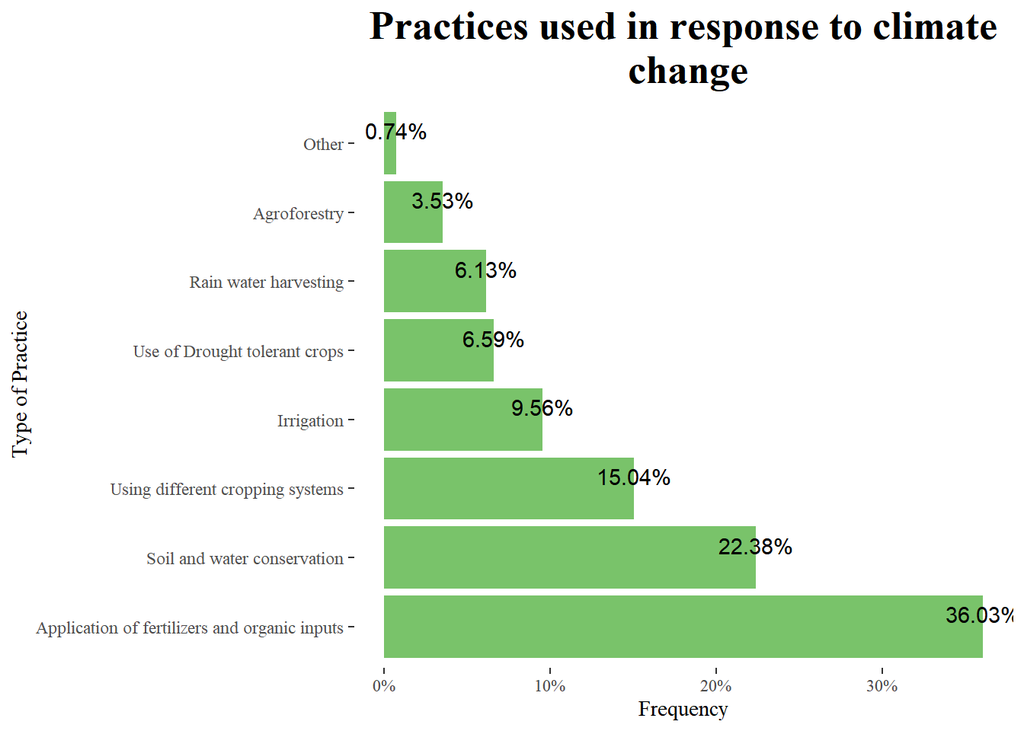

```r
c_response %>%drop_na(type) %>%  ggplot(aes(fct_infreq(type)))+
   geom_bar(aes(y = (..count..)/sum(..count..)), fill = "#79c36a") +
  geom_text(aes(y = ((..count..)/sum(..count..)), label = scales::percent((..count..)/sum(..count..))), stat = "count", vjust = -0.25) +
  scale_y_continuous(labels = percent) +
  labs(title = "Practices used in response to climate\n change",
       x = "Type of Practice",
       y = "Frequency")+
  theme_tufte()+
  theme(plot.title = element_text(face = "bold", size = 20, hjust = 0.5))+
  coord_flip()
```

With respect to climate change the following are the practices that were used and the most used practice is application of fertilizers and organic inputs, soil and water conservation and thirdly using different cropping systems.

```r
freq(df3$group_climatechange.cc_response_other)
```

```
## Frequencies
## df3$group_climatechange.cc_response_other
## Type: Character
##
##                                         Freq   % Valid   % Valid Cum.   % Total   % Total Cum.
## ------------------------------------- ------ --------- -------------- --------- --------------
##                        (Empty string)    585     98.65          98.65     98.65          98.65
##                By using APCNF methods      4      0.67          99.33      0.67          99.33
##       Good Water management practices      1      0.17          99.49      0.17          99.49
##                         He don't know      3      0.51         100.00      0.51         100.00
##                                  <NA>      0                               0.00         100.00
##                                 Total    593    100.00         100.00    100.00         100.00
```

Other practices that were considered are APCNF methods and good water management practices.

```r
table(df3$agric_advice.agricultural_advice)
```

```
##
##   0   1
##  10 583
```

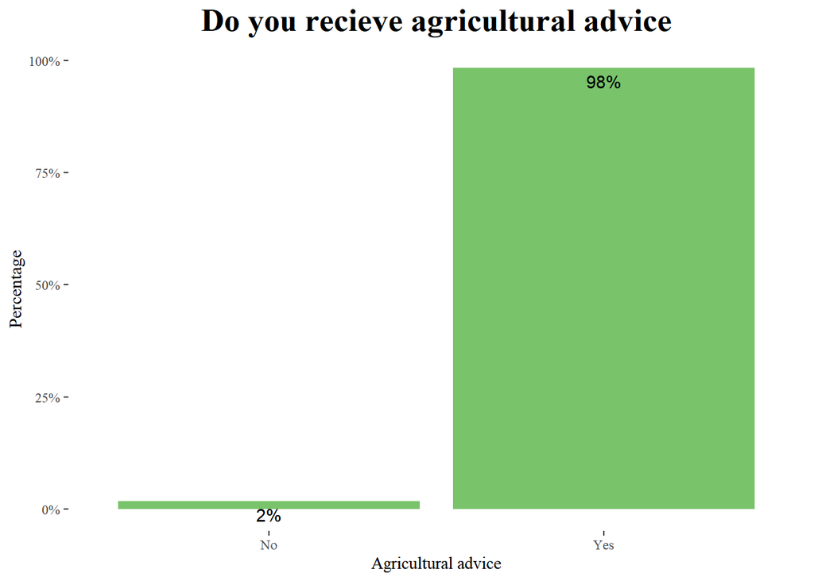

```r
df3$agric_advice.agricultural_advice <- as.factor(df3$agric_advice.agricultural_advice)
levels(df3$agric_advice.agricultural_advice) <- c("No", "Yes")

df3 %>% ggplot(aes(agric_advice.agricultural_advice))+
  geom_bar(fill = "#79c36a", aes(y = (..count..)/sum(..count..)))+
  geom_text(aes(y = ((..count..)/sum(..count..)), label = scales::percent((..count..)/sum(..count..))), stat = "count", vjust = 1.5, colour = "black")+
  scale_y_continuous(labels = percent) +
  labs(title = "Do you recieve agricultural advice",
       x = "Agricultural advice",
       y ="Percentage")+
  theme_tufte()+
  theme(plot.title = element_text(face = "bold", size = 20, hjust = 0.5))
```

98% of the people receive agricultural advice.

```r
df3 <- df3 %>%
  bind_cols(split_into_multiple(.$agric_advice.agricultural_advice_source, " ", "agric_source"))

df3$agric_source_1 <- as.factor(df3$agric_source_1)
levels(df3$agric_source_1) <- c("TV", "Other", "Radio", "Lead farmers or other farmers", "Self help groups", "Government Extension", "Phone", "Internet")

df3$agric_source_2 <- as.factor(df3$agric_source_2)
levels(df3$agric_source_2) <- c("TV", "Radio", "Lead farmers or other farmers", "Self help groups", "Government Extension","School children/youth", "Written materials",  "Phone", "Internet")

df3$agric_source_3 <- as.factor(df3$agric_source_3)
levels(df3$agric_source_3) <- c("TV","Development agencies", "Radio", "Lead farmers or other farmers", "Self help groups", "Government Extension","School children/youth", "Written materials",  "Phone", "Internet")

df3$agric_source_4 <- as.factor(df3$agric_source_4)
levels(df3$agric_source_4) <- c("TV","Development agencies", "Other", "Lead farmers or other farmers", "Self help groups", "Government Extension","School children/youth", "Written materials",  "Phone", "Internet")

df3$agric_source_5 <- as.factor(df3$agric_source_5)
levels(df3$agric_source_5) <- c("TV","Development agencies", "Radio","Self help groups",  "Government Extension","School children/youth", "Written materials",  "Phone", "Internet")

df3$agric_source_6 <- as.factor(df3$agric_source_6)
levels(df3$agric_source_6) <- c("Development agencies", "Other", "Lead farmers or other farmers", "School children/youth", "Written materials", "Phone", "Internet")

df3$agric_source_7 <- as.factor(df3$agric_source_7)
levels(df3$agric_source_7) <- c("Development agencies", "Other","Phone", "Internet")

df3$agric_source_8 <- as.factor(df3$agric_source_8)
levels(df3$agric_source_8) <- c("TV", "Development agencies")


Agric_source <- df3 %>% select(c(agric_source_1, agric_source_2, agric_source_3, agric_source_4, agric_source_5, agric_source_6, agric_source_7, agric_source_8)) %>% gather(agriculture_source, type)
freq(Agric_source$type) %>% kbl(caption = "Agricultural advice source") %>%
  kable_classic(full_width = F, html_font = "Cambria")
```

Agricultural advice source

|  | Freq | % Valid | % Valid Cum. | % Total | % Total Cum. |
| --- | --- | --- | --- | --- | --- |
| Development agencies | 182 | 8.9347079 | 8.934708 | 3.8364250 | 3.836425 |
| Government Extension | 351 | 17.2312224 | 26.165930 | 7.3988196 | 11.235245 |
| Internet | 81 | 3.9764359 | 30.142366 | 1.7074199 | 12.942664 |
| Lead farmers or other farmers | 537 | 26.3622975 | 56.504664 | 11.3195616 | 24.262226 |
| Other | 9 | 0.4418262 | 56.946490 | 0.1897133 | 24.451939 |
| Phone | 242 | 11.8802160 | 68.826706 | 5.1011804 | 29.553120 |
| Radio | 29 | 1.4236622 | 70.250368 | 0.6112985 | 30.164418 |
| School children/youth | 34 | 1.6691213 | 71.919489 | 0.7166948 | 30.881113 |
| Self help groups | 52 | 2.5527737 | 74.472263 | 1.0961214 | 31.977234 |
| TV | 418 | 20.5203731 | 94.992636 | 8.8111298 | 40.788364 |
| Written materials | 102 | 5.0073638 | 100.000000 | 2.1500843 | 42.938449 |
| <NA> | 2707 | NA | NA | 57.0615514 | 100.000000 |
| Total | 4744 | 100.0000000 | 100.000000 | 100.0000000 | 100.000000 |

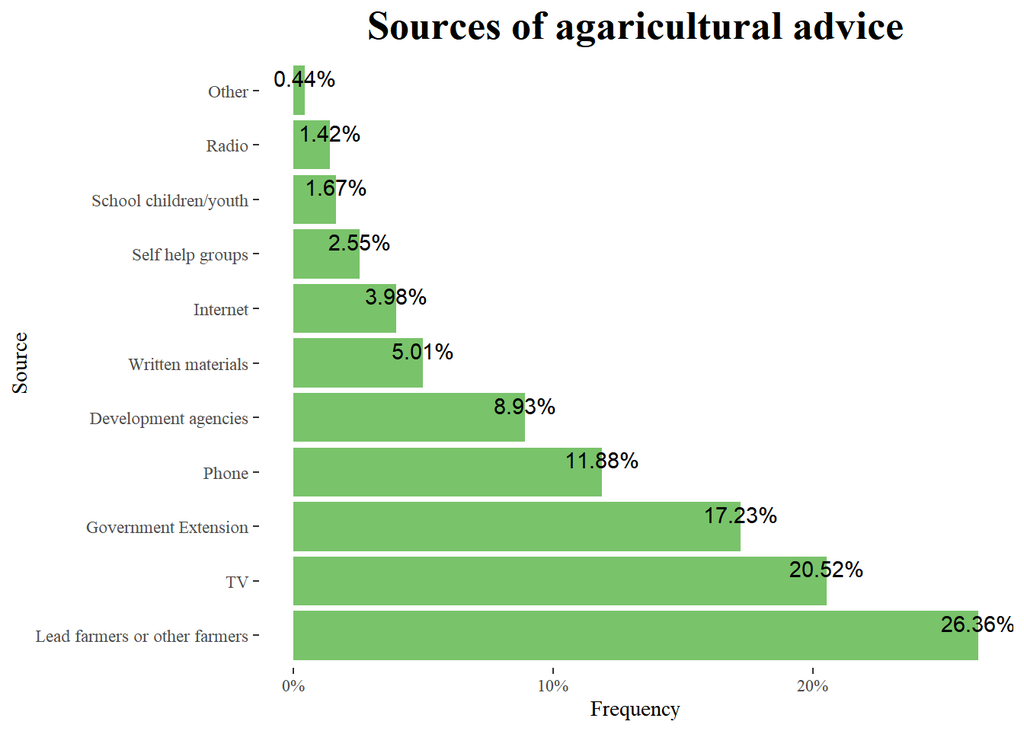

```r
Agric_source %>%drop_na(type) %>%  ggplot(aes(fct_infreq(type)))+
   geom_bar(aes(y = (..count..)/sum(..count..)), fill = "#79c36a") +
  geom_text(aes(y = ((..count..)/sum(..count..)), label = scales::percent((..count..)/sum(..count..))), stat = "count", vjust = -0.25) +
  scale_y_continuous(labels = percent) +
  labs(title = "Sources of agaricultural advice",
       x = "Source",
       y = "Frequency")+
  theme_tufte()+
  theme(plot.title = element_text(face = "bold", size = 20, hjust = 0.5))+
  coord_flip()
```

From the 98% who receive the agricultural advice, they do receive it mostly from lead farmers/other farmers, TV, Government extension, phone and development agencies.

```r
table(df3$agric_advice.advice_source_other)
```

```
##
##
##                                                                         584
## 1. Rhythu Mitra groups \n2. Farmer Producer Organisation \n3. Adivasi Mitra
##                                                                           2
##                                                                       APCNF
##                                                                           6
##                                                                     Nothing
##                                                                           1
```

Other sources of advice that they get from is APCNF and farmer organisations.

```r
table(df3$agric_advice.information_source_preferred)
```

```
##
##   1   2   3   4   5   6   7   8   9  10  11
##  48   5 332  44  70   1   4  46   7  28   8
```

```r
df3$agric_advice.information_source_preferred <- as.factor(df3$agric_advice.information_source_preferred)

levels(df3$agric_advice.information_source_preferred) <- c("TV", "Radio", "Lead farmers or other farmers", "Self help groups", "Government Extension","School children/youth", "Written materials",  "Phone", "Internet", "Development agencies", "Other")

freq(df3$agric_advice.information_source_preferred)
```

```
## Frequencies
## df3$agric_advice.information_source_preferred
## Type: Factor
##
##                                       Freq   % Valid   % Valid Cum.   % Total   % Total Cum.
## ----------------------------------- ------ --------- -------------- --------- --------------
##                                  TV     48      8.09           8.09      8.09           8.09
##                               Radio      5      0.84           8.94      0.84           8.94
##       Lead farmers or other farmers    332     55.99          64.92     55.99          64.92
##                    Self help groups     44      7.42          72.34      7.42          72.34
##                Government Extension     70     11.80          84.15     11.80          84.15
##               School children/youth      1      0.17          84.32      0.17          84.32
##                   Written materials      4      0.67          84.99      0.67          84.99
##                               Phone     46      7.76          92.75      7.76          92.75
##                            Internet      7      1.18          93.93      1.18          93.93
##                Development agencies     28      4.72          98.65      4.72          98.65
##                               Other      8      1.35         100.00      1.35         100.00
##                                <NA>      0                               0.00         100.00
##                               Total    593    100.00         100.00    100.00         100.00
```

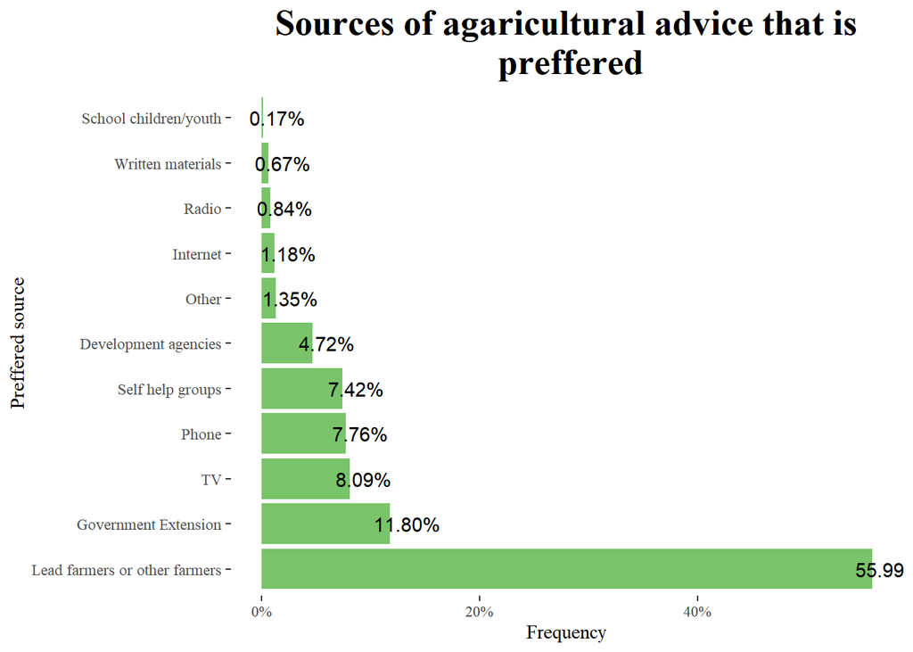

```r
df3 %>%  ggplot(aes(fct_infreq(agric_advice.information_source_preferred)))+
   geom_bar(aes(y = (..count..)/sum(..count..)), fill = "#79c36a") +
  geom_text(aes(y = ((..count..)/sum(..count..)), label = scales::percent((..count..)/sum(..count..))), stat = "count", hjust = 0.25) +
  scale_y_continuous(labels = percent) +
  labs(title = "Sources of agaricultural advice that is\n preffered",
       x = "Preffered source",
       y = "Frequency")+
  theme_tufte()+
  theme(plot.title = element_text(face = "bold", size = 20, hjust = 0.5))+
  coord_flip()
```

```r
df3$farmer_groups.farmer_group <- as.factor(df3$farmer_groups.farmer_group)
levels(df3$farmer_groups.farmer_group) <- c("NO", "YES")

freq(df3$farmer_groups.farmer_group)
```

```
## Frequencies
## df3$farmer_groups.farmer_group
## Type: Factor
##
##               Freq   % Valid   % Valid Cum.   % Total   % Total Cum.
## ----------- ------ --------- -------------- --------- --------------
##          NO    200     33.73          33.73     33.73          33.73
##         YES    393     66.27         100.00     66.27         100.00
##        <NA>      0                               0.00         100.00
##       Total    593    100.00         100.00    100.00         100.00
```

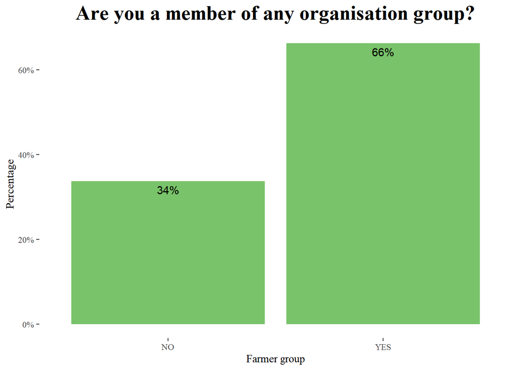

```r
df3 %>% ggplot(aes(farmer_groups.farmer_group))+
  geom_bar(fill = "#79c36a", aes(y = (..count..)/sum(..count..)))+
  geom_text(aes(y = ((..count..)/sum(..count..)), label = scales::percent((..count..)/sum(..count..))), stat = "count", vjust = 1.5, colour = "black")+
  scale_y_continuous(labels = percent) +
  labs(title = "Are you a member of any organisation group?",
       x = "Farmer group",
       y="Percentage")+
  theme_tufte()+
  theme(plot.title = element_text(face = "bold", size = 20, hjust = 0.5))
```

66% of the farmers belong to farmer groups.

```r
df3$farmer_groups.farmer_group_type <- as.factor(df3$farmer_groups.farmer_group_type)
levels(df3$farmer_groups.farmer_group_type) <- c("Cooperative", "Farmer group", "Women self help group", "Other")

freq(df3$farmer_groups.farmer_group_type)
```

```
## Frequencies
## df3$farmer_groups.farmer_group_type
## Type: Factor
##
##                               Freq   % Valid   % Valid Cum.   % Total   % Total Cum.
## --------------------------- ------ --------- -------------- --------- --------------
##                 Cooperative    105     26.72          26.72     17.71          17.71
##                Farmer group    181     46.06          72.77     30.52          48.23
##       Women self help group     74     18.83          91.60     12.48          60.71
##                       Other     33      8.40         100.00      5.56          66.27
##                        <NA>    200                              33.73         100.00
##                       Total    593    100.00         100.00    100.00         100.00
```

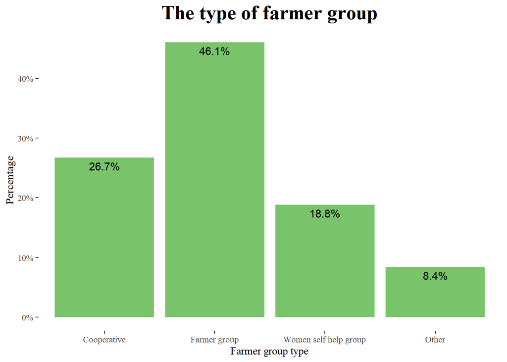

```r
df3 %>%drop_na(farmer_groups.farmer_group_type) %>%  ggplot(aes(farmer_groups.farmer_group_type))+
  geom_bar(fill = "#79c36a", aes(y = (..count..)/sum(..count..)))+
  geom_text(aes(y = ((..count..)/sum(..count..)), label = scales::percent((..count..)/sum(..count..))), stat = "count", vjust = 1.5, colour = "black")+
  scale_y_continuous(labels = percent) +
  labs(title = "The type of farmer group",
       x = "Farmer group type",
       y="Percentage")+
  theme_tufte()+
  theme(plot.title = element_text(face = "bold", size = 20, hjust = 0.5))
```

With the different organisation types 46% belonged to farmer groups, 26.7% to cooperatives and 18.8% to women self help groups.

```r
table(df3$farmer_groups.group_type_other)
```

```
##
##                                       APCNF Raithu Baroda kendram
##                   560                     3                     2
## Raithu Barosa kendram
##                    28
```

```r
table(df3$farmer_groups.group_benefits)
```

```
##
##                   1       1 2     1 2 3   1 2 3 4 1 2 3 4 7   1 2 3 7     1 2 4
##       200         1        49        10         2         7         6        12
##   1 2 4 5 1 2 4 5 7   1 2 4 7 1 2 4 7 5     1 2 5   1 2 5 7     1 2 7   1 2 7 4
##         2         4        81         4         1         1        10         2
##     1 3 2     1 4 7       1 5     1 7 4       1 8       2 1     2 4 1       2 5
##         5        28        46         2         6         3         3         3
##         5       5 1     5 1 2         8
##        96         5         1         3
```

```r
df3 <- df3 %>%
  bind_cols(split_into_multiple(.$farmer_groups.group_benefits, " ", "group_benefits"))
df3$group_benefits_1 <- as.factor(df3$group_benefits_1)
levels(df3$group_benefits_1) <- c("Knowledge & information", "Training", "Credit facilities", "Other")

df3$group_benefits_2 <- as.factor(df3$group_benefits_2)
levels(df3$group_benefits_2) <- c("Knowledge & information", "Training", "Labour", "Tools and equipment", "Credit facilities","Marketing", "Other")

df3$group_benefits_3 <- as.factor(df3$group_benefits_3)
levels(df3$group_benefits_3) <- c("Knowledge & information", "Training", "Labour", "Tools and equipment","Credit facilities", "Marketing")

df3$group_benefits_4 <- as.factor(df3$group_benefits_4)
levels(df3$group_benefits_4) <- c( "Tools and equipment","Credit facilities", "Marketing")

df3$group_benefits_5 <- as.factor(df3$group_benefits_5)
levels(df3$group_benefits_5) <- c("Credit facilities","Marketing")

g_benefits <- df3 %>% select(c(group_benefits_1, group_benefits_2, group_benefits_3, group_benefits_4, group_benefits_5)) %>% gather(group_benefit, type)
freq(g_benefits$type) %>% kbl(caption = "Farmer group benefits") %>%
  kable_classic(full_width = F, html_font = "Cambria")
```

Farmer group benefits

|  | Freq | % Valid | % Valid Cum. | % Total | % Total Cum. |
| --- | --- | --- | --- | --- | --- |
| Credit facilities | 163 | 16.4480323 | 16.44803 | 5.4974705 | 5.497471 |
| Knowledge & information | 291 | 29.3642785 | 45.81231 | 9.8145025 | 15.311973 |
| Labour | 30 | 3.0272452 | 48.83956 | 1.0118044 | 16.323777 |
| Marketing | 145 | 14.6316852 | 63.47124 | 4.8903879 | 21.214165 |
| Other | 9 | 0.9081736 | 64.37941 | 0.3035413 | 21.517707 |
| Tools and equipment | 147 | 14.8335015 | 79.21292 | 4.9578415 | 26.475548 |
| Training | 206 | 20.7870838 | 100.00000 | 6.9477234 | 33.423271 |
| <NA> | 1974 | NA | NA | 66.5767285 | 100.000000 |
| Total | 2965 | 100.0000000 | 100.00000 | 100.0000000 | 100.000000 |

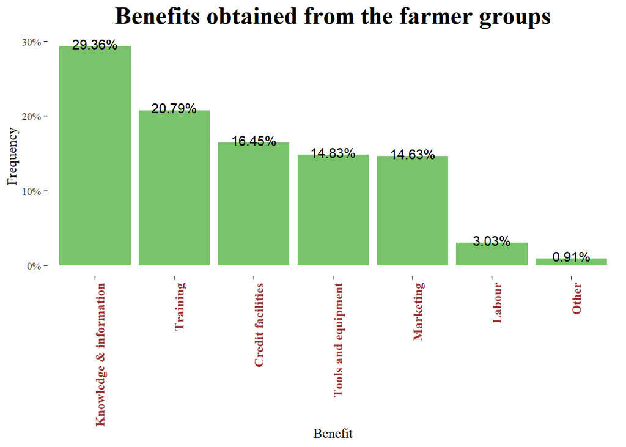

```r
p2 <- g_benefits %>%drop_na(type) %>%  ggplot(aes(fct_infreq(type)))+
   geom_bar(aes(y = (..count..)/sum(..count..)), fill = "#79c36a") +
  geom_text(aes(y = ((..count..)/sum(..count..)), label = scales::percent((..count..)/sum(..count..))), stat = "count", vjust = 0.25) +
  scale_y_continuous(labels = percent) +
  labs(title = "Benefits obtained from the farmer groups",
       x = "Benefit",
       y = "Frequency")+
  theme_tufte()+
  theme(plot.title = element_text(face = "bold", size = 20, hjust = 0.5))

# Rotate and adjust x axis text
p2 + theme(axis.text.x = element_text(face = "bold", color = "#993333",
                           size = 10,angle = 90, hjust = 1))
```

One of the interests was to look at the benefits they get from the groups, the most common was knowledge and information at 29.36%, credit facilities at 16.5% and training at 20.8%. These were the top 3 benefits.

```r
table(df3$farmer_groups.group_benefits_other)
```

```
##
##                                                             Exposure visits
##                                   478                                    14
## Sharing of knowledge\nExposure visits
##                                     3
```

Other types of benefits are exposure visits and sharing of knowledge.

```r
table(df3$observation_comment)
```

```
##
##
##                                                                                                                         151
## As farmer became older, He is unable to adopt all the new technologies and methods which are used for increasing crop yield
##                                                                                                                           2
##                                                                                              Farmer following APCNF methods
##                                                                                                                           3
##                                                                                        Farmer following the organic methods
##                                                                                                                           3
##                                     Farmer is working as MT in APCNF. He is guiding farmers related agricultural activities
##                                                                                                                           3
##                                                                         Fertilizer are available in the cooperative society
##                                                                                                                           3
##                                                     Gollori Padma don't have her own land. She has taken the land for lease
##                                                                                                                           1
##                                                                                             He has only single farm access.
##                                                                                                                           2
##                                                  He is very old man. His lands are given for the his relatives on good will
##                                                                                                                           1
##   His son Satyanarayana is working as Lecturer in local college in contract base. This is added as secondary income for him
##                                                                                                                           2
##                                                    Household head is in gulf country for work purpose ( the farmers father)
##                                                                                                                           1
##                                                              In chemical plots FYM is applied when it is available for him.
##                                                                                                                           3
##                                                                                                                        Nope
##                                                                                                                           2
##                                                                      The land has been left fallow for 2 months not 2 years
##                                                                                                                           4
##                This farmer is not following APCNF methods, because he is working in some private agency. He don't have time
##                                                                                                                           3
```

```r
table(df3$endnote)
```

```
## < table of extent 0 >
```

```r
#table(df3$end)
```

```r
#table(df3$meta.instanceID)

df3$group_farm.farm_location <- as.factor(df3$group_farm.farm_location)
levels(df3$group_farm.farm_location) <- c("Home backyard", "Near habitation", "In the forest/tribal area")

freq(df3$group_farm.farm_location)
```

```
## Frequencies
## df3$group_farm.farm_location
## Type: Factor
##
##                                   Freq   % Valid   % Valid Cum.   % Total   % Total Cum.
## ------------------------------- ------ --------- -------------- --------- --------------
##                   Home backyard    152     25.72          25.72     25.63          25.63
##                 Near habitation    362     61.25          86.97     61.05          86.68
##       In the forest/tribal area     77     13.03         100.00     12.98          99.66
##                            <NA>      2                               0.34         100.00
##                           Total    593    100.00         100.00    100.00         100.00
```

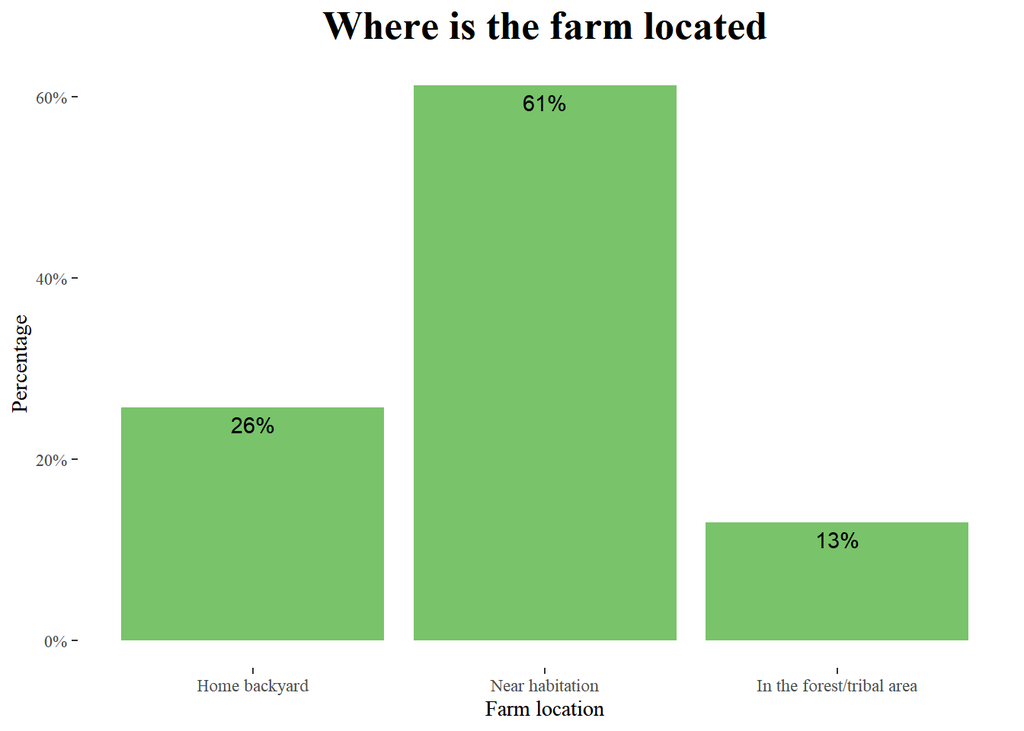

```r
df3 %>%drop_na(group_farm.farm_location) %>%  ggplot(aes(group_farm.farm_location))+
  geom_bar(fill = "#79c36a", aes(y = (..count..)/sum(..count..)))+
  geom_text(aes(y = ((..count..)/sum(..count..)), label = scales::percent((..count..)/sum(..count..))), stat = "count", vjust = 1.5, colour = "black")+
  scale_y_continuous(labels = percent) +
  labs(title = "Where is the farm located",
       x = "Farm location",
       y="Percentage")+
  theme_tufte()+
  theme(plot.title = element_text(face = "bold", size = 20, hjust = 0.5))
```

61% of the farms were located near habitations, 26% at the home backyards and 13% in the forest/tribal areas.

```r
summary(df3$group_farm.farm_size)
```

```
##    Min. 1st Qu.  Median    Mean 3rd Qu.    Max.
##   0.000   1.000   2.000   3.883   4.000  80.000
```

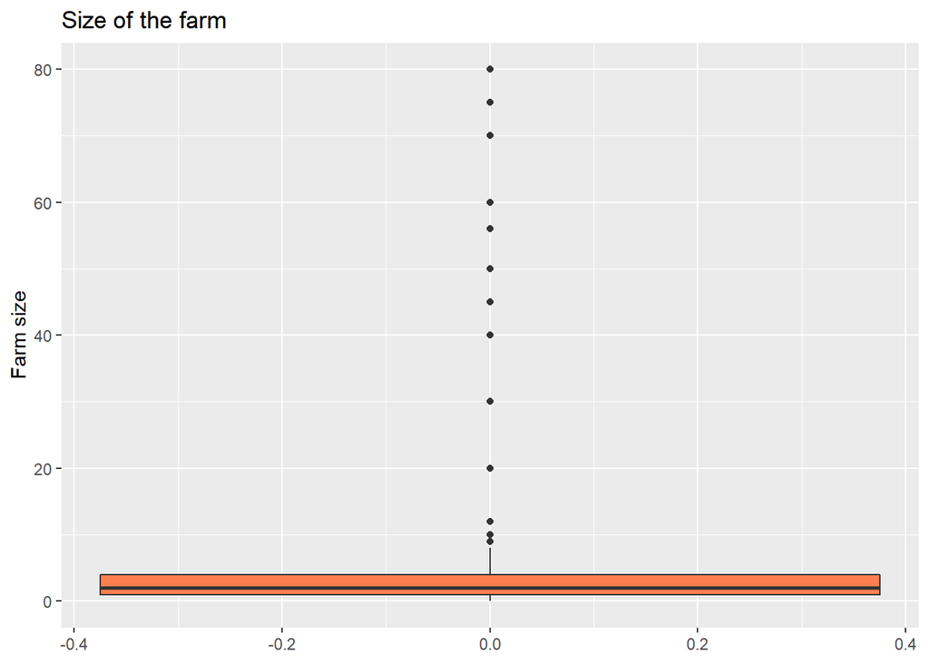

```r
df3 %>% ggplot(aes(y =group_farm.farm_size))+
  geom_boxplot(fill = "coral")+
  labs(title = "Size of the farm",
       y = "Farm size")
```

```r
df3$group_farm.farm_size_unit <- as.factor(df3$group_farm.farm_size_unit)
levels(df3$group_farm.farm_size_unit) <- c("Acres", "Hectares", "Other")

freq(df3$group_farm.farm_size_unit)
```

```
## Frequencies
## df3$group_farm.farm_size_unit
## Type: Factor
##
##                  Freq   % Valid   % Valid Cum.   % Total   % Total Cum.
## -------------- ------ --------- -------------- --------- --------------
##          Acres    571     96.45          96.45     96.29          96.29
##       Hectares      1      0.17          96.62      0.17          96.46
##          Other     20      3.38         100.00      3.37          99.83
##           <NA>      1                               0.17         100.00
##          Total    593    100.00         100.00    100.00         100.00
```

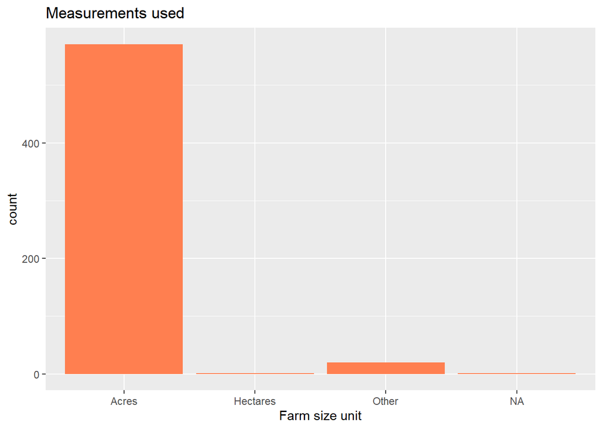

```r
df3 %>% ggplot(aes(group_farm.farm_size_unit))+
  geom_bar(fill = "coral")+
  labs(title = "Measurements used",
       x = "Farm size unit")
```

The farm size was measured in acres where only 1 case was in hectares.

```r
table(df3$group_farm.measurement_unit_other)
```

```
##
##       Cents
##   573    20
```

```r
df3$group_farm.land_ownership <- as.factor(df3$group_farm.land_ownership)
levels(df3$group_farm.land_ownership) <- c("Private/Purchase", "Private/Inheritance", "Communal", "Tribal area", "Rented", "Other")
freq(df3$group_farm.land_ownership)
```

```
## Frequencies
## df3$group_farm.land_ownership
## Type: Factor
##
##                             Freq   % Valid   % Valid Cum.   % Total   % Total Cum.
## ------------------------- ------ --------- -------------- --------- --------------
##          Private/Purchase     60     10.12          10.12     10.12          10.12
##       Private/Inheritance    313     52.78          62.90     52.78          62.90
##                  Communal      3      0.51          63.41      0.51          63.41
##               Tribal area    107     18.04          81.45     18.04          81.45
##                    Rented    102     17.20          98.65     17.20          98.65
##                     Other      8      1.35         100.00      1.35         100.00
##                      <NA>      0                               0.00         100.00
##                     Total    593    100.00         100.00    100.00         100.00
```

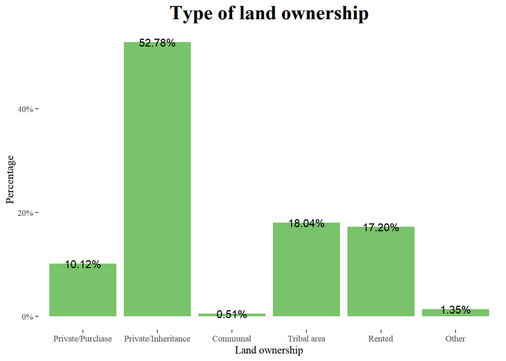

```r
df3 %>%drop_na(group_farm.land_ownership) %>%  ggplot(aes(group_farm.land_ownership))+
  geom_bar(fill = "#79c36a", aes(y = (..count..)/sum(..count..)))+
  geom_text(aes(y = ((..count..)/sum(..count..)), label = scales::percent((..count..)/sum(..count..))), stat = "count", vjust = 0.5, colour = "black")+
  scale_y_continuous(labels = percent) +
  labs(title = "Type of land ownership",
       x = "Land ownership",
       y="Percentage")+
  theme_tufte()+
  theme(plot.title = element_text(face = "bold", size = 20, hjust = 0.5))
```

With regard to land ownership most of the land was private through inheritance representing 52.78%, then tribal area 18% then rented at 17.20%.

```r
df3$group_farm.land_ownership_other <- as.factor(df3$group_farm.land_ownership_other)
levels(df3$group_farm.land_ownership_other) <- c("NA", "Heridity", "NA", "No land", "Own","Own")
freq(df3$group_farm.land_ownership_other)
```

```
## Frequencies
## df3$group_farm.land_ownership_other
## Type: Factor
##
##                  Freq   % Valid   % Valid Cum.   % Total   % Total Cum.
## -------------- ------ --------- -------------- --------- --------------
##             NA    586     98.82          98.82     98.82          98.82
##       Heridity      3      0.51          99.33      0.51          99.33
##        No land      1      0.17          99.49      0.17          99.49
##            Own      3      0.51         100.00      0.51         100.00
##           <NA>      0                               0.00         100.00
##          Total    593    100.00         100.00    100.00         100.00
```

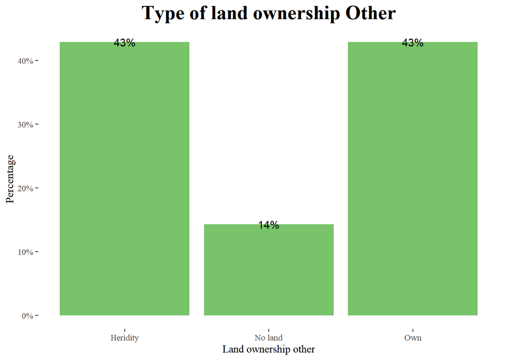

```r
df3 %>%filter(group_farm.land_ownership_other !="NA") %>%  ggplot(aes(group_farm.land_ownership_other))+
  geom_bar(fill = "#79c36a", aes(y = (..count..)/sum(..count..)))+
  geom_text(aes(y = ((..count..)/sum(..count..)), label = scales::percent((..count..)/sum(..count..))), stat = "count", vjust = 0.5, colour = "black")+
  scale_y_continuous(labels = percent) +
  labs(title = "Type of land ownership Other",
       x = "Land ownership other",
       y="Percentage")+
  theme_tufte()+
  theme(plot.title = element_text(face = "bold", size = 20, hjust = 0.5))
```

With other land ownership schemes owned and heredity having 43%.

```r
summary(df3$group_farm.cropping_area)
```

```
##    Min. 1st Qu.  Median    Mean 3rd Qu.    Max.
##   0.000   1.000   2.000   2.983   5.000  30.000
```

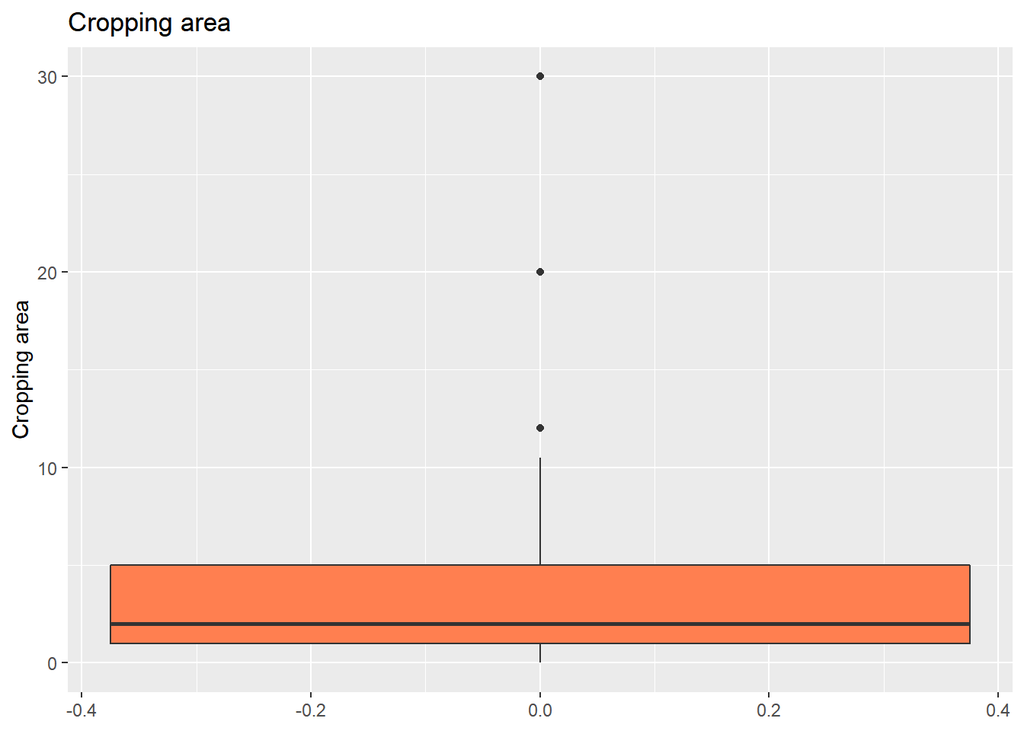

```r
df3 %>% ggplot(aes(y =group_farm.cropping_area))+
  geom_boxplot(fill = "coral")+
  labs(title = "Cropping area",
       y = "Cropping area")
```

The cropping area had a minimum of 0 and maximum of 30 acres, though some cases were outliers.

```r
table(df3$group_farm.cropping_area_unit)
```

```
##
##   2   4
## 586   6
```

```r
df3$group_farm.cropping_area_unit <- as.factor(df3$group_farm.cropping_area_unit)
levels(df3$group_farm.cropping_area_unit) <- c("Acres", "Other")
freq(df3$group_farm.cropping_area_unit)
```

```
## Frequencies
## df3$group_farm.cropping_area_unit
## Type: Factor
##
##               Freq   % Valid   % Valid Cum.   % Total   % Total Cum.
## ----------- ------ --------- -------------- --------- --------------
##       Acres    586     98.99          98.99     98.82          98.82
##       Other      6      1.01         100.00      1.01          99.83
##        <NA>      1                               0.17         100.00
##       Total    593    100.00         100.00    100.00         100.00
```

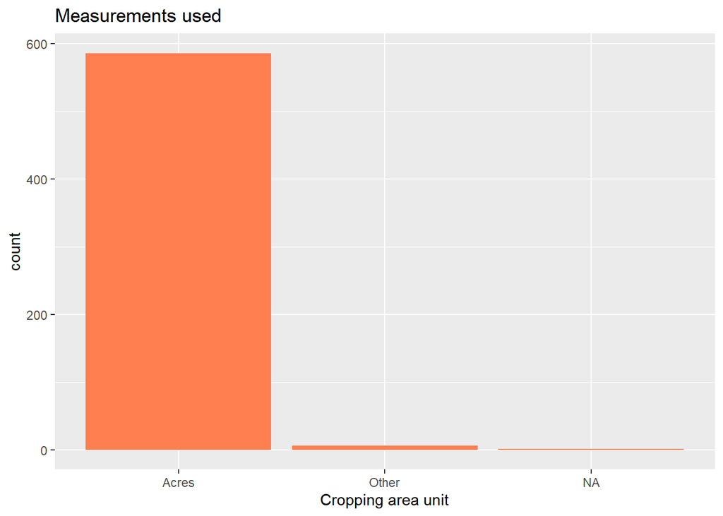

```r
df3 %>% ggplot(aes(group_farm.cropping_area_unit))+
  geom_bar(fill = "coral")+
  labs(title = "Measurements used",
       x = "Cropping area unit")
```

Bigger percentage of the units are in acres that is 99%.

```r
table(df3$group_farm.cropping_area_other)
```

```
##
##       Cents    No
##   587     5     1
```

```r
df3$group_farm.land_use <- as.factor(df3$group_farm.land_use)
levels(df3$group_farm.land_use) <- c("Agriculture","Agriculture",  "Forest land", "Forest land", "Pastureland", "Other")
freq(df3$group_farm.land_use)
```

```
## Frequencies
## df3$group_farm.land_use
## Type: Factor
##
##                     Freq   % Valid   % Valid Cum.   % Total   % Total Cum.
## ----------------- ------ --------- -------------- --------- --------------
##       Agriculture    532     89.71          89.71     89.71          89.71
##       Forest land     57      9.61          99.33      9.61          99.33
##       Pastureland      2      0.34          99.66      0.34          99.66
##             Other      2      0.34         100.00      0.34         100.00
##              <NA>      0                               0.00         100.00
##             Total    593    100.00         100.00    100.00         100.00
```

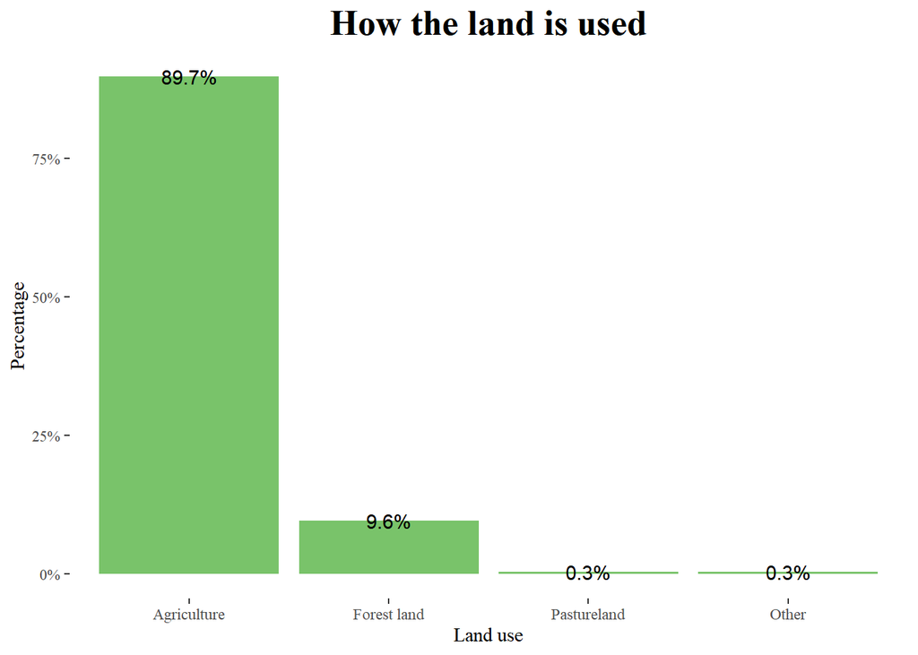

```r
df3 %>%  ggplot(aes(group_farm.land_use))+
  geom_bar(fill = "#79c36a", aes(y = (..count..)/sum(..count..)))+
  geom_text(aes(y = ((..count..)/sum(..count..)), label = scales::percent((..count..)/sum(..count..))), stat = "count", vjust = 0.5, colour = "black")+
  scale_y_continuous(labels = percent) +
  labs(title = "How the land is used",
       x = "Land use",
       y="Percentage")+
  theme_tufte()+
  theme(plot.title = element_text(face = "bold", size = 20, hjust = 0.5))
```

89.7% of the land is used for agriculture and 9.6% is used on forest land while only 0.3% is used as patureland.

```r
table(df3$group_farm.land_use_other)
```

```
##
##      Nill   No
##  591    1    1
```

```r
table(df3$group_soil.soil_quality)
```

```
##
##   High    Low Medium
##      5     81    507
```

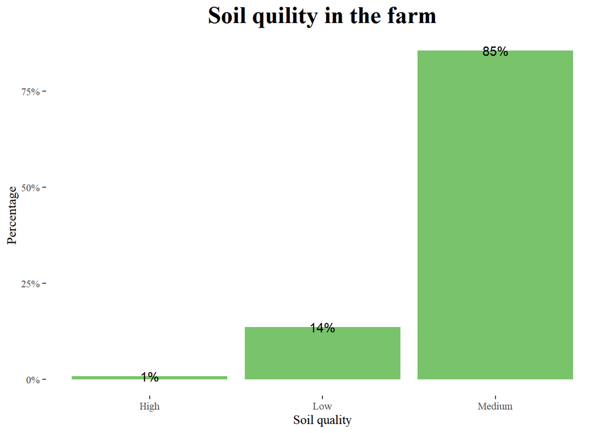

```r
df3 %>%  ggplot(aes(group_soil.soil_quality))+
  geom_bar(fill = "#79c36a", aes(y = (..count..)/sum(..count..)))+
  geom_text(aes(y = ((..count..)/sum(..count..)), label = scales::percent((..count..)/sum(..count..))), stat = "count", vjust = 0.5, colour = "black")+
  scale_y_continuous(labels = percent) +
  labs(title = "Soil quility in the farm",
       x = "Soil quality",
       y="Percentage")+
  theme_tufte()+
  theme(plot.title = element_text(face = "bold", size = 20, hjust = 0.5))
```

From the table and plot it shows that the soil quality is mostly medium which is 85%.

```r
## string variable
table(df3$group_soil.soil_quality_indicators)
```

```
##
##                                                                         1. Based on soil colour and soil type\n2. Based on crevices present in the field
##                                                                                                                                                        1
##                                                                                        1. Based on the soil colour\n2. Based on the porosity of the soil
##                                                                                                                                                        1
##                                                                1. Crevices present in the soil.\n2. Based on the soil colour\n3. Water porosity capacity
##                                                                                                                                                        1
##                                            1.Based on the porosity of the soil\n2. Based on the earthworms and \nearthworm castings present in the field
##                                                                                                                                                        1
##                                                                                                         Based of water infiltration rate and Earthworms.
##                                                                                                                                                        1
##                                                                                                                                    Based on  soil colour
##                                                                                                                                                        1
##                                                                                                                                Based on colour and yield
##                                                                                                                                                        1
##                                                                                                  Based on colour, soil organisms present, yield obtained
##                                                                                                                                                        1
##                                                                                                                                     Based on earth worms
##                                                                                                                                                        1
##                                                                                                       Based on earth worms and while ploughing the land.
##                                                                                                                                                        1
##                                                                                                                               Based on earth worms count
##                                                                                                                                                        1
##                                                                                           Based on earthworm castings and earthworms present in the soil
##                                                                                                                                                        1
##                                                                       Based on earthworm castings present in the soil and earthworms present in the soil
```

[output cut: 251 more lines]

#### soil types

```r
df3$group_soil.soil_types <- as.factor(df3$group_soil.soil_types)
levels(df3$group_soil.soil_types) <- c("NO", "YES")

freq(df3$group_soil.soil_types)
```

```
## Frequencies
## df3$group_soil.soil_types
## Type: Factor
##
##               Freq   % Valid   % Valid Cum.   % Total   % Total Cum.
## ----------- ------ --------- -------------- --------- --------------
##          NO    544     91.74          91.74     91.74          91.74
##         YES     49      8.26         100.00      8.26         100.00
##        <NA>      0                               0.00         100.00
##       Total    593    100.00         100.00    100.00         100.00
```

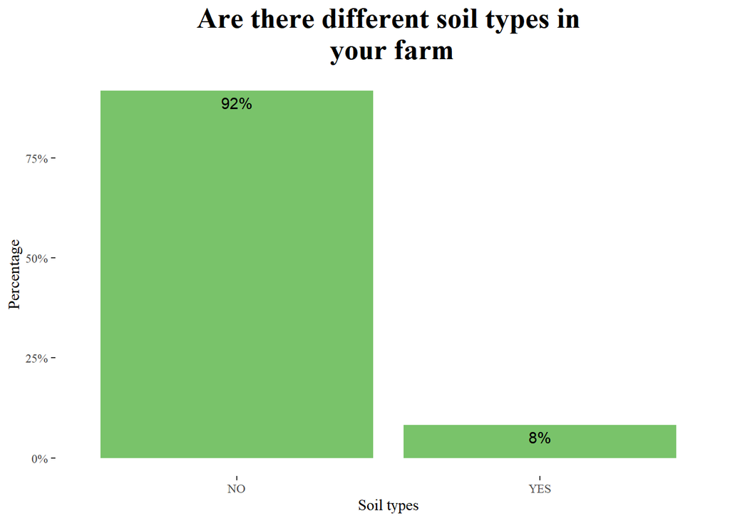

```r
df3 %>% ggplot(aes(group_soil.soil_types))+
  geom_bar(fill = "#79c36a", aes(y = (..count..)/sum(..count..)))+
  geom_text(aes(y = ((..count..)/sum(..count..)), label = scales::percent((..count..)/sum(..count..))), stat = "count", vjust = 1.5, colour = "black")+
  scale_y_continuous(labels = percent) +
  labs(title = "Are there different soil types in\n your farm",
       x = "Soil types",
       y="Percentage")+
  theme_tufte()+
  theme(plot.title = element_text(face = "bold", size = 20, hjust = 0.5))
```

92% of the people said that there were no different types of soil in the farm where only 8% said that there was different soil types on there farms.

```r
freq(df3$group_soil.num_soil_types)
```

```
## Frequencies
## df3$group_soil.num_soil_types
## Type: Integer
##
##               Freq   % Valid   % Valid Cum.   % Total   % Total Cum.
## ----------- ------ --------- -------------- --------- --------------
##           1      4      8.16           8.16      0.67           0.67
##           2     45     91.84         100.00      7.59           8.26
##        <NA>    544                              91.74         100.00
##       Total    593    100.00         100.00    100.00         100.00
```

Among the 8% of those with different type of soil, 92% said that there was 2 types of the soils while 8% said 1 type.

```r
table(df3$group_soil.soil_types_description)
```

```
##
##                                               Balck and Red soils
##                              544                                1
##             Black and red colour        Black and red sandy soils
##                                1                                4
##              Black and red soils              Black and red Soils
##                                7                                1
##              Black and Red soils         Black and red type soils
##                                1                                3
##        Black soil and sandy soil           Black soil; sandy soil
##                                1                                1
##                      Black soils  Black soils and red sandy soils
##                                2                                1
##        Black soils and Red soils      Black soils and sandy soils
##                                2                                1
##          Black soils, sandy soil           Black soils; red soils
##                                1                                2
##           Black soils; Red soils                         Red soil
##                                5                                1
##                        Red soils        Red soils and black soils
##                                1                                6
##        Red Soils and black soils                 Red; Black soils
##                                1                                1
##              Sand and black soil                 Sand; Black soil
##                                1                                1
##                  Sand;black soil Sandy soils, black lateral soils
##                                1                                1
##                Stone land, sandy
##                                1
```

```r
df3$group_soil.soil_surface <- as.factor(df3$group_soil.soil_surface)
levels(df3$group_soil.soil_surface) <- c("Crusted", "Not crusted")

freq(df3$group_soil.soil_surface)
```

```
## Frequencies
## df3$group_soil.soil_surface
## Type: Factor
##
##                     Freq   % Valid   % Valid Cum.   % Total   % Total Cum.
## ----------------- ------ --------- -------------- --------- --------------
##           Crusted     99     16.69          16.69     16.69          16.69
##       Not crusted    494     83.31         100.00     83.31         100.00
##              <NA>      0                               0.00         100.00
##             Total    593    100.00         100.00    100.00         100.00
```

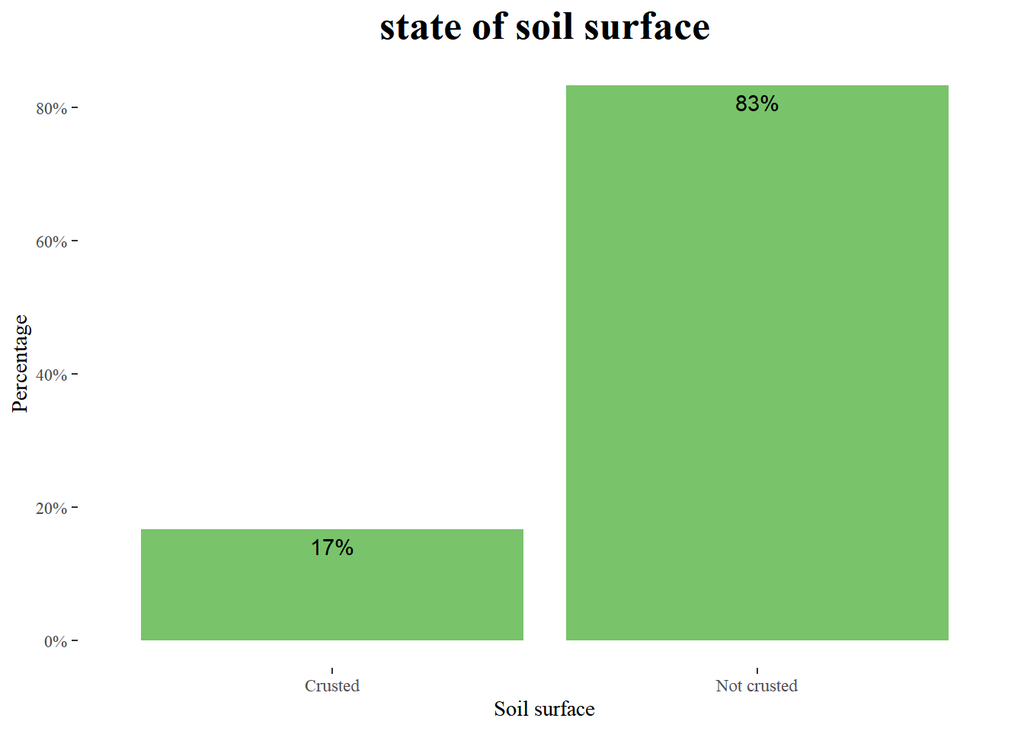

```r
df3 %>% ggplot(aes(group_soil.soil_surface))+
  geom_bar(fill = "#79c36a", aes(y = (..count..)/sum(..count..)))+
  geom_text(aes(y = ((..count..)/sum(..count..)), label = scales::percent((..count..)/sum(..count..))), stat = "count", vjust = 1.5, colour = "black")+
  scale_y_continuous(labels = percent) +
  labs(title = "state of soil surface",
       x = "Soil surface",
       y="Percentage")+
  theme_tufte()+
  theme(plot.title = element_text(face = "bold", size = 20, hjust = 0.5))
```

Only 17% of the soil is crusted while 83% is not crusted as in regards to state of the soil surface.

```r
df3$group_soil.rock_gravel <- as.factor(df3$group_soil.rock_gravel)
levels(df3$group_soil.rock_gravel) <- c("Less than 5", "Between 5-40", "More than 40")

freq(df3$group_soil.rock_gravel)
```

```
## Frequencies
## df3$group_soil.rock_gravel
## Type: Factor
##
##                      Freq   % Valid   % Valid Cum.   % Total   % Total Cum.
## ------------------ ------ --------- -------------- --------- --------------
##        Less than 5    379     63.91          63.91     63.91          63.91
##       Between 5-40    212     35.75          99.66     35.75          99.66
##       More than 40      2      0.34         100.00      0.34         100.00
##               <NA>      0                               0.00         100.00
##              Total    593    100.00         100.00    100.00         100.00
```

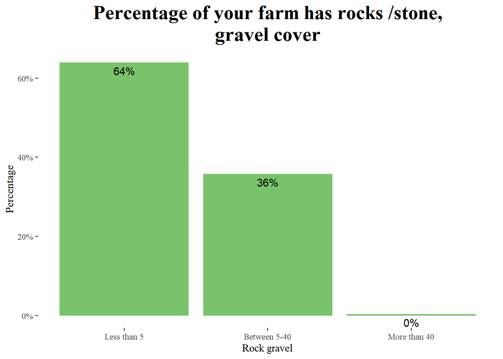

```r
df3 %>% ggplot(aes(group_soil.rock_gravel))+
  geom_bar(fill = "#79c36a", aes(y = (..count..)/sum(..count..)))+
  geom_text(aes(y = ((..count..)/sum(..count..)), label = scales::percent((..count..)/sum(..count..))), stat = "count", vjust = 1.5, colour = "black")+
  scale_y_continuous(labels = percent) +
  labs(title = "Percentage of your farm has rocks /stone,\n gravel cover ",
       x = "Rock gravel",
       y="Percentage")+
  theme_tufte()+
  theme(plot.title = element_text(face = "bold", size = 20, hjust = 0.5))
```

In terms of perecentage of the farms that contains rock gravel we see that farms with less than 5% was 64% while between 5 and 40 was 36%. we only had 2 cases were more than 40%.

```r
df3$group_soil_erosion.erosion_prevalence <- as.factor(df3$group_soil_erosion.erosion_prevalence)
levels(df3$group_soil_erosion.erosion_prevalence) <- c("NO", "YES")

freq(df3$group_soil_erosion.erosion_prevalence)
```

```
## Frequencies
## df3$group_soil_erosion.erosion_prevalence
## Type: Factor
##
##               Freq   % Valid   % Valid Cum.   % Total   % Total Cum.
## ----------- ------ --------- -------------- --------- --------------
##          NO    516     87.02          87.02     87.02          87.02
##         YES     77     12.98         100.00     12.98         100.00
##        <NA>      0                               0.00         100.00
##       Total    593    100.00         100.00    100.00         100.00
```

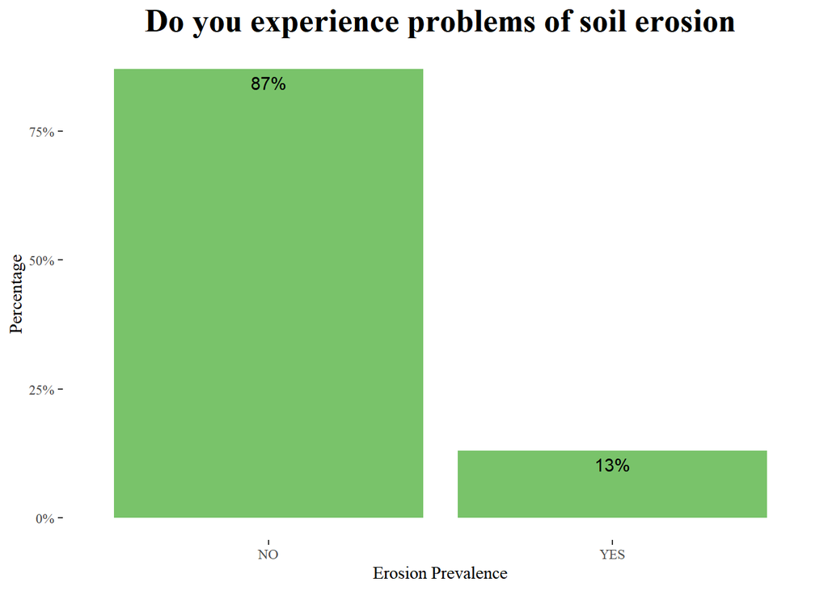

```r
df3 %>% ggplot(aes(group_soil_erosion.erosion_prevalence))+
  geom_bar(fill = "#79c36a", aes(y = (..count..)/sum(..count..)))+
  geom_text(aes(y = ((..count..)/sum(..count..)), label = scales::percent((..count..)/sum(..count..))), stat = "count", vjust = 1.5, colour = "black")+
  scale_y_continuous(labels = percent) +
  labs(title = "Do you experience problems of soil erosion",
       x = "Erosion Prevalence",
       y="Percentage")+
  theme_tufte()+
  theme(plot.title = element_text(face = "bold", size = 20, hjust = 0.5))
```

87% of the farmers indicated that they do not experience soil erosion problems.

```r
df3$group_soil_erosion.erosion_type_farm <- as.factor(df3$group_soil_erosion.erosion_type_farm)
levels(df3$group_soil_erosion.erosion_type_farm) <- c("Gully","Rill", "Sheet")

freq(df3$group_soil_erosion.erosion_type_farm)
```

```
## Frequencies
## df3$group_soil_erosion.erosion_type_farm
## Type: Factor
##
##               Freq   % Valid   % Valid Cum.   % Total   % Total Cum.
## ----------- ------ --------- -------------- --------- --------------
##       Gully     56     72.73          72.73      9.44           9.44
##        Rill     20     25.97          98.70      3.37          12.82
##       Sheet      1      1.30         100.00      0.17          12.98
##        <NA>    516                              87.02         100.00
##       Total    593    100.00         100.00    100.00         100.00
```

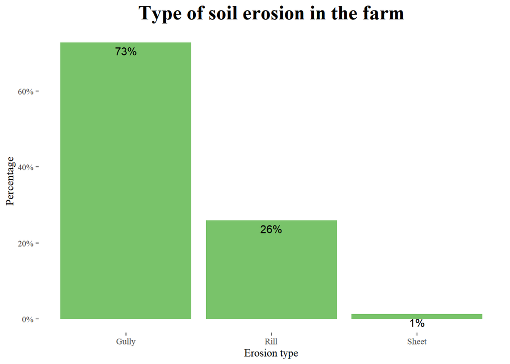

```r
df3 %>%drop_na(group_soil_erosion.erosion_type_farm) %>%  ggplot(aes(group_soil_erosion.erosion_type_farm))+
  geom_bar(fill = "#79c36a", aes(y = (..count..)/sum(..count..)))+
  geom_text(aes(y = ((..count..)/sum(..count..)), label = scales::percent((..count..)/sum(..count..))), stat = "count", vjust = 1.5, colour = "black")+
  scale_y_continuous(labels = percent) +
  labs(title = "Type of soil erosion in the farm",
       x = "Erosion type",
       y="Percentage")+
  theme_tufte()+
  theme(plot.title = element_text(face = "bold", size = 20, hjust = 0.5))
```

Among the 13% that experience soil erosion problems 73% experience gully erosion, 26% experience rill erosion and 1% face sheet erosion.

```r
table(df3$group_soil_erosion.erosion_control_measures)
```

```
##
##     2 3   3
## 516   2  75
```

```r
df3$group_soil_erosion.erosion_control_measures <- as.factor(df3$group_soil_erosion.erosion_control_measures)

levels(df3$group_soil_erosion.erosion_control_measures) <- c(NA, "vegetative", "Structural")
freq(df3$group_soil_erosion.erosion_control_measures)
```

```
## Frequencies
## df3$group_soil_erosion.erosion_control_measures
## Type: Factor
##
##                    Freq   % Valid   % Valid Cum.   % Total   % Total Cum.
## ---------------- ------ --------- -------------- --------- --------------
##       vegetative      2      2.60           2.60      0.34           0.34
##       Structural     75     97.40         100.00     12.65          12.98
##             <NA>    516                              87.02         100.00
##            Total    593    100.00         100.00    100.00         100.00
```

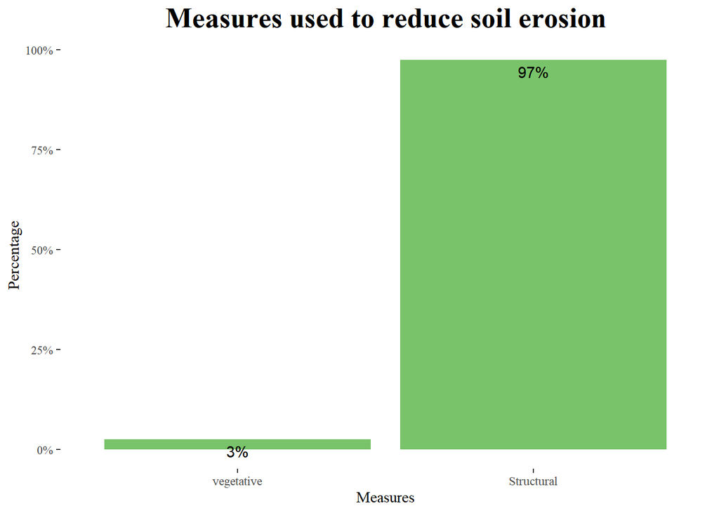

```r
df3 %>%drop_na(group_soil_erosion.erosion_control_measures) %>%  ggplot(aes(group_soil_erosion.erosion_control_measures))+
  geom_bar(fill = "#79c36a", aes(y = (..count..)/sum(..count..)))+
  geom_text(aes(y = ((..count..)/sum(..count..)), label = scales::percent((..count..)/sum(..count..))), stat = "count", vjust = 1.5, colour = "black")+
  scale_y_continuous(labels = percent) +
  labs(title = "Measures used to reduce soil erosion",
       x = "Measures",
       y="Percentage")+
  theme_tufte()+
  theme(plot.title = element_text(face = "bold", size = 20, hjust = 0.5))
```

Most used method in reducing the soil erosion is strusctural method which covers 97%.

```r
table(df3$group_soil_erosion.erosion_control_description)
```

```
##
##
##                                            591
##             We are arranging bunds with stones
##                                              1
## We used to make channels for storage of water.
##                                              1
```

```r
table(df3$group_crop_production.crop_type)
```

```
##
##                                           1               1 10 14
##                     3                   193                     1
##            1 10 16 14                  1 14                  1 16
##                     1                     6                     2
##                   1 2                1 2 10           1 2 10 11 6
##                    19                     1                     1
##             1 2 10 14                1 2 14           1 2 14 10 9
##                     3                    17                     1
##             1 2 14 15     1 2 14 15 9 10 16             1 2 14 16
##                     1                     1                     4
##              1 2 14 6              1 2 14 9          1 2 15 14 16
##                     1                     1                     1
##            1 2 5 6 11              1 2 6 14        1 2 6 14 10 16
##                     1                     1                     1
```

[output cut: 32 more lines]

```r
df3 <- df3 %>%
  bind_cols(split_into_multiple(.$group_crop_production.crop_type, " ", "Crop_type"))
df3$Crop_type_1 <- as.factor(df3$Crop_type_1)
levels(df3$Crop_type_1) <- c("Paddy", "Guord", "Turmeric", "Pepper", "Other", "Finger millet", "Pearl millet", "Brinjal", "Red gram", "Cow peas")

df3$Crop_type_2 <- as.factor(df3$Crop_type_2)
levels(df3$Crop_type_2) <- c("Paddy","Tubers", "Okra","Guord", "Turmeric","Pepper", "Other","Finger millet", "Maize","Brinjal",  "Red gram", "Cow peas")

df3$Crop_type_3 <- as.factor(df3$Crop_type_3)
levels(df3$Crop_type_3) <- c("Tubers", "Okra", "Guord", "Turmeric", "Pepper", "Other",  "Maize", "Brinjal", "Red gram", "Cow peas", "Beans")

df3$Crop_type_4 <- as.factor(df3$Crop_type_4)
levels(df3$Crop_type_4) <- c("Tubers", "Okra",  "Turmeric", "Pepper", "Other", "Maize", "Brinjal", "Red gram", "Cow peas", "Beans")

df3$Crop_type_5 <- as.factor(df3$Crop_type_5)
levels(df3$Crop_type_5) <- c("Tubers", "Okra", "Other", "Pearl millet", "Maize", "Brinjal", "Red gram", "Beans")

df3$Crop_type_6 <- as.factor(df3$Crop_type_6)
levels(df3$Crop_type_6) <- c("Tubers", "Okra",  "Guord","Turmeric", "Other", "Pearl millet", "Brinjal")

df3$Crop_type_7 <- as.factor(df3$Crop_type_7)
levels(df3$Crop_type_7) <- c("Tubers", "Turmeric", "Other", "Maize",  "Cow peas")

df3$Crop_type_8 <- as.factor(df3$Crop_type_8)
levels(df3$Crop_type_8) <- c("Tubers",  "Other", "Pearl millet")

df3$Crop_type_9 <- as.factor(df3$Crop_type_9)
levels(df3$Crop_type_9) <- c("Okra")

crop_type <- df3 %>% select(c( Crop_type_1, Crop_type_2, Crop_type_3, Crop_type_4, Crop_type_5, Crop_type_6, Crop_type_7, Crop_type_8,Crop_type_9)) %>% gather(crop_type, type)
freq(crop_type$type) %>% kbl(caption = "Crop types") %>%
  kable_classic(full_width = F, html_font = "Cambria")
```

Crop types

|  | Freq | % Valid | % Valid Cum. | % Total | % Total Cum. |
| --- | --- | --- | --- | --- | --- |
| Beans | 5 | 0.5279831 | 0.5279831 | 0.0936856 | 0.0936856 |
| Brinjal | 10 | 1.0559662 | 1.5839493 | 0.1873712 | 0.2810568 |
| Cow peas | 12 | 1.2671595 | 2.8511088 | 0.2248454 | 0.5059022 |
| Finger millet | 104 | 10.9820486 | 13.8331573 | 1.9486603 | 2.4545625 |
| Guord | 36 | 3.8014784 | 17.6346357 | 0.6745363 | 3.1290987 |
| Maize | 23 | 2.4287223 | 20.0633580 | 0.4309537 | 3.5600525 |
| Okra | 21 | 2.2175290 | 22.2808870 | 0.3934795 | 3.9535319 |
| Other | 300 | 31.6789863 | 53.9598733 | 5.6211355 | 9.5746674 |
| Paddy | 266 | 28.0887012 | 82.0485744 | 4.9840734 | 14.5587409 |
| Pearl millet | 6 | 0.6335797 | 82.6821542 | 0.1124227 | 14.6711636 |
| Pepper | 54 | 5.7022175 | 88.3843717 | 1.0118044 | 15.6829680 |
| Red gram | 24 | 2.5343189 | 90.9186906 | 0.4496908 | 16.1326588 |
| Tubers | 22 | 2.3231257 | 93.2418163 | 0.4122166 | 16.5448754 |
| Turmeric | 64 | 6.7581837 | 100.0000000 | 1.1991756 | 17.7440510 |
| <NA> | 4390 | NA | NA | 82.2559490 | 100.0000000 |
| Total | 5337 | 100.0000000 | 100.0000000 | 100.0000000 | 100.0000000 |

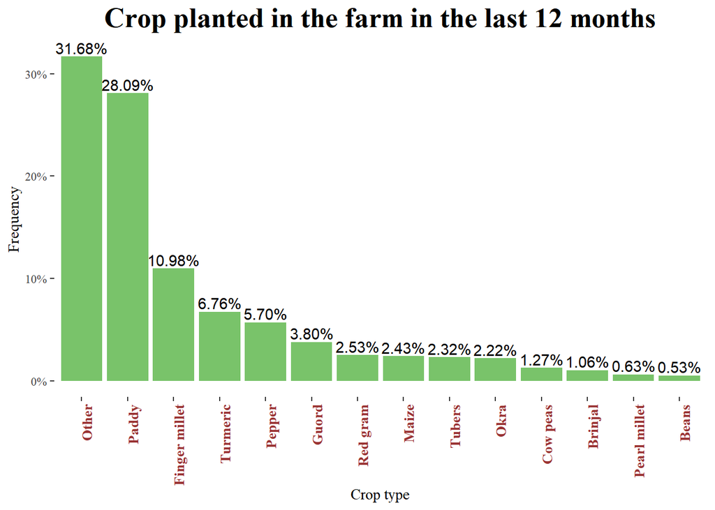

```r
crop_type %>%drop_na(type) %>%  ggplot(aes(fct_infreq(type)))+
   geom_bar(aes(y = (..count..)/sum(..count..)), fill = "#79c36a") +
  geom_text(aes(y = ((..count..)/sum(..count..)), label = scales::percent((..count..)/sum(..count..))), stat = "count", vjust = -0.25) +
  scale_y_continuous(labels = percent) +
  labs(title = "Crop planted in the farm in the last 12 months",
       x = "Crop type",
       y = "Frequency")+
  theme_tufte()+
  theme(plot.title = element_text(face = "bold", size = 20, hjust = 0.5),
        axis.text.x = element_text(face = "bold", color = "#993333",
                           size = 10,angle = 90, hjust = 1))
```

Comparing the crops planted in the farm in the last 12 months we have Paddy as the most common crop planted followed by finger millet, Turmeric and pepper.

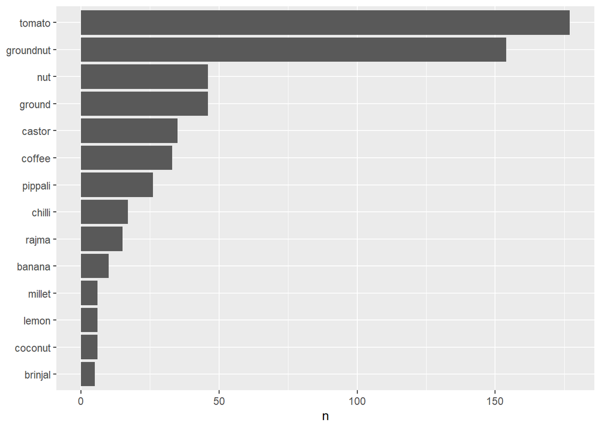

```r
library(tidytext)
other_crop <- df3 %>% select(group_crop_production.crop_type_other)
tk <- other_crop %>% unnest_tokens(word, group_crop_production.crop_type_other)

# tk %>% anti_join(stop_words) %>%
#   count(word, sort = TRUE) %>% top_n(20)

tk %>% anti_join(stop_words) %>%
  count(word, sort = TRUE) %>%
  filter(n > 2) %>%
  mutate(word = reorder(word, n)) %>%
  ggplot(aes(n, word)) +
  geom_col() +
  labs(y = NULL)
```

```r
df3 <- df3 %>%
   bind_cols(split_into_multiple(.$group_crop_production.crop_production, " ", "Crop_prod"))

df3$Crop_prod_1 <- as.factor(df3$Crop_prod_1)
levels(df3$Crop_prod_1) <- c("Low soil fertility", "None", "Other", "Unreliable rainfall", "Drought", "Low soil moisture", "Pests", "Diseases", "High cost of farm inputs")


df3$Crop_prod_2 <- as.factor(df3$Crop_prod_2)
levels(df3$Crop_prod_2) <- c("Low soil fertility", "Other", "Unreliable rainfall", "Drought", "Low soil moisture", "Wrong crop selection", "Pests", "Diseases", "High cost of farm inputs", "Lack of available labour")

df3$Crop_prod_3 <- as.factor(df3$Crop_prod_3)
levels(df3$Crop_prod_3) <- c("Low soil fertility", "Unreliable rainfall", "Drought", "Low soil moisture","Wrong crop selection", "Pests", "Diseases", "High cost of farm inputs", "Lack of available labour")


df3$Crop_prod_4 <- as.factor(df3$Crop_prod_4)
levels(df3$Crop_prod_4) <- c("Low soil fertility", "Unreliable rainfall", "Drought", "Low soil moisture","Wrong crop selection", "Pests", "Diseases", "High cost of farm inputs", "Lack of available labour")


df3$Crop_prod_5 <- as.factor(df3$Crop_prod_5)
levels(df3$Crop_prod_5) <- c("Low soil fertility", "None", "Unreliable rainfall", "Low soil moisture", "Pests", "Diseases", "High cost of farm inputs", "Lack of available labour")


df3$Crop_prod_6 <- as.factor(df3$Crop_prod_6)
levels(df3$Crop_prod_6) <- c("Low soil fertility", "Drought", "Pests", "Diseases", "High cost of farm inputs", "Lack of available labour")

df3$Crop_prod_7 <- as.factor(df3$Crop_prod_7)
levels(df3$Crop_prod_7) <- c("High cost of farm inputs", "Lack of available labour")

df3$Crop_prod_8 <- as.factor(df3$Crop_prod_8)
levels(df3$Crop_prod_8) <- c("Lack of available labour")

crop_prod <- df3 %>% select(c( Crop_prod_1, Crop_prod_2, Crop_prod_3, Crop_prod_4, Crop_prod_5, Crop_prod_6, Crop_prod_7, Crop_prod_8)) %>% gather(crop_prod, type)
freq(crop_prod$type) %>% kbl(caption = "Crop production") %>%
  kable_classic(full_width = F, html_font = "Cambria")
```

Crop production

|  | Freq | % Valid | % Valid Cum. | % Total | % Total Cum. |
| --- | --- | --- | --- | --- | --- |
| Diseases | 409 | 20.2274975 | 20.22750 | 8.6214165 | 8.621417 |
| Drought | 52 | 2.5717112 | 22.79921 | 1.0961214 | 9.717538 |
| High cost of farm inputs | 309 | 15.2818991 | 38.08111 | 6.5134907 | 16.231029 |
| Lack of available labour | 107 | 5.2917903 | 43.37290 | 2.2554806 | 18.486509 |
| Low soil fertility | 245 | 12.1167161 | 55.48961 | 5.1644182 | 23.650928 |
| Low soil moisture | 119 | 5.8852621 | 61.37488 | 2.5084317 | 26.159359 |
| None | 4 | 0.1978239 | 61.57270 | 0.0843170 | 26.243676 |
| Other | 12 | 0.5934718 | 62.16617 | 0.2529511 | 26.496627 |
| Pests | 428 | 21.1671612 | 83.33333 | 9.0219224 | 35.518550 |
| Unreliable rainfall | 333 | 16.4688427 | 99.80218 | 7.0193929 | 42.537943 |
| Wrong crop selection | 4 | 0.1978239 | 100.00000 | 0.0843170 | 42.622260 |
| <NA> | 2722 | NA | NA | 57.3777403 | 100.000000 |
| Total | 4744 | 100.0000000 | 100.00000 | 100.0000000 | 100.000000 |

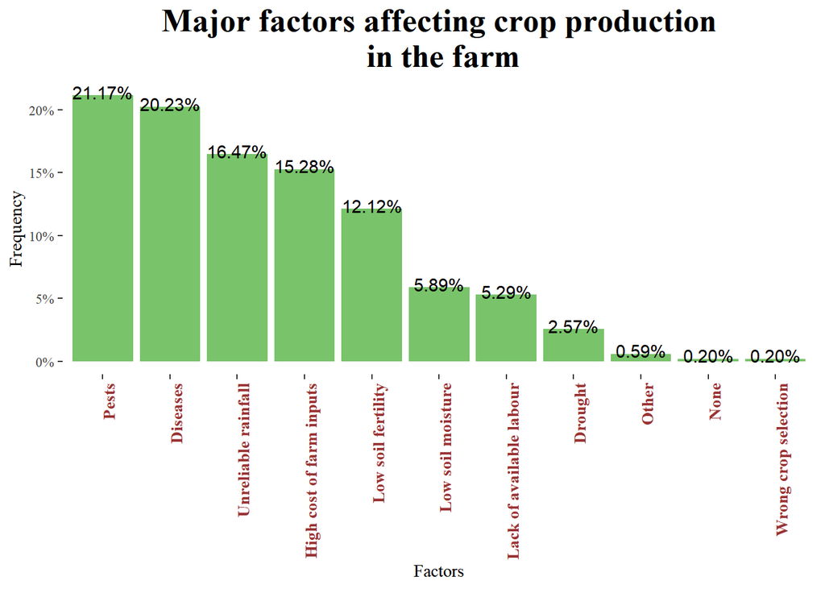

```r
crop_prod %>%drop_na(type) %>%  ggplot(aes(fct_infreq(type)))+
   geom_bar(aes(y = (..count..)/sum(..count..)), fill = "#79c36a") +
  geom_text(aes(y = ((..count..)/sum(..count..)), label = scales::percent((..count..)/sum(..count..))), stat = "count", vjust = 0.25) +
  scale_y_continuous(labels = percent) +
  labs(title = "Major factors affecting crop production\n in the farm",
       x = "Factors",
       y = "Frequency")+
  theme_tufte()+
  theme(plot.title = element_text(face = "bold", size = 20, hjust = 0.5),
        axis.text.x = element_text(face = "bold", color = "#993333",
                           size = 10,angle = 90, hjust = 1))
```

Pests seem to be the major factor affecting crop production on the farm followed by diseases, unreliable rainfall and high cost of farm inputs.

```r
table(df3$group_crop_production.crop_production_other)
```

```
##
##
##                                                                                           581
##                Field get flooded as it's in low level compared to the orchids around the farm
##                                                                                             1
##                        Field gets flooded because it's lower than the other orchids around it
##                                                                                             1
##                                                                     He never even think of it
##                                                                                             2
##                                                                        Never even think of it
##                                                                                             1
##                                                                                          Nill
##                                                                                             1
##                                                                                  Strong winds
##                                                                                             2
##                                                               Usage of bore water(salt water)
##                                                                                             1
##                                         Water from fish pond is affecting the crop production
##                                                                                             1
##                                                                       Water is being polluted
##                                                                                             1
## Water is getting mixed up with the water of fish ponds which is affecting the crop production
##                                                                                             1
```

```r
table(df3$group_crop_production.crop_productivity_enhance)
```

```
##
##       1     1 2   1 2 4   1 2 5   1 2 6     1 4     1 5   1 5 2       2     2 1
##      29     121       6      58       2      10       3       1      26      42
##   2 1 4   2 1 5   2 1 6     2 3   2 3 1 2 3 1 5   2 3 4 2 3 4 5   2 3 5 2 3 5 4
##       3      11       1      43       1       1      11      21      12       2
##     2 4 2 4 5 3     2 5   2 5 1   2 5 6     2 6   2 6 5       3     3 2   3 2 4
##       8       1       9       1       1      26       1      59       2       1
##     3 4   3 4 5 3 4 5 6     3 5   3 5 4     3 6       4 4 3 5 6     4 5   4 5 6
##       4      16      20       3       2      11       1       1       3       1
##       5     5 2   5 2 1 5 2 3 1     5 4       6     6 2
##       5       1       1       1       1       5       4
```

```r
df3 <- df3 %>%
   bind_cols(split_into_multiple(.$group_crop_production.crop_productivity_enhance, " ", "Crop_prod_enhance"))

df3$Crop_prod_enhance_1 <- as.factor(df3$Crop_prod_enhance_1)
levels(df3$Crop_prod_enhance_1) <- c("Chemical fertilizers", "Farmyard manure", "Compost", "Use of improved varieties", "Local varieties suited to the area", "Other")

df3$Crop_prod_enhance_2 <- as.factor(df3$Crop_prod_enhance_2)
levels(df3$Crop_prod_enhance_2) <- c("Chemical fertilizers", "Farmyard manure", "Compost", "Use of improved varieties", "Local varieties suited to the area", "Other")

df3$Crop_prod_enhance_3 <- as.factor(df3$Crop_prod_enhance_3)
levels(df3$Crop_prod_enhance_3) <- c("Chemical fertilizers", "Farmyard manure", "Compost", "Use of improved varieties", "Local varieties suited to the area", "Other")


df3$Crop_prod_enhance_4 <- as.factor(df3$Crop_prod_enhance_4)
levels(df3$Crop_prod_enhance_4) <- c("Chemical fertilizers","Compost", "Use of improved crop varieties", "Local varieties suited to the area", "Other")

enhance <- df3 %>% select(Crop_prod_enhance_1, Crop_prod_enhance_2, Crop_prod_enhance_3, Crop_prod_enhance_4) %>% gather(crop_enhance, type)
freq(enhance$type) %>% kbl(caption = "Crop production enhance") %>%
  kable_classic(full_width = F, html_font = "Cambria")
```

Crop production enhance

|  | Freq | % Valid | % Valid Cum. | % Total | % Total Cum. |
| --- | --- | --- | --- | --- | --- |
| Chemical fertilizers | 292 | 22.723735 | 22.72374 | 12.310287 | 12.31029 |
| Compost | 212 | 16.498054 | 39.22179 | 8.937605 | 21.24789 |
| Farmyard manure | 419 | 32.607004 | 71.82879 | 17.664418 | 38.91231 |
| Local varieties suited to the area | 177 | 13.774319 | 85.60311 | 7.462057 | 46.37437 |
| Other | 73 | 5.680934 | 91.28405 | 3.077572 | 49.45194 |
| Use of improved crop varieties | 2 | 0.155642 | 91.43969 | 0.084317 | 49.53626 |
| Use of improved varieties | 110 | 8.560311 | 100.00000 | 4.637437 | 54.17369 |
| <NA> | 1087 | NA | NA | 45.826307 | 100.00000 |
| Total | 2372 | 100.000000 | 100.00000 | 100.000000 | 100.00000 |

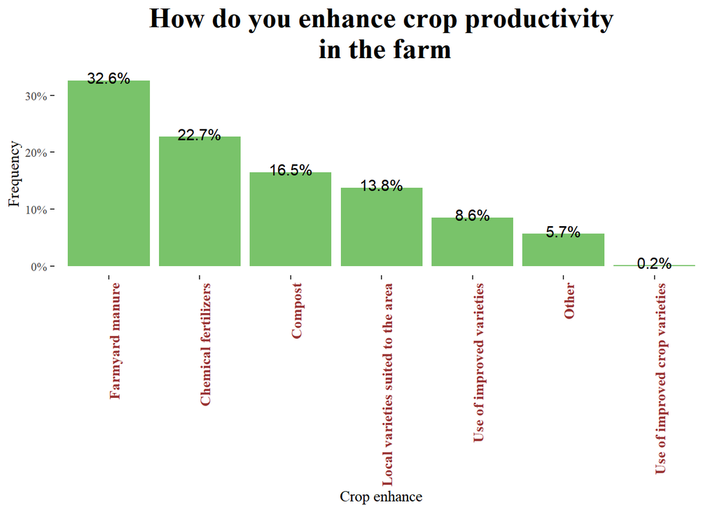

```r
enhance %>%drop_na(type) %>%  ggplot(aes(fct_infreq(type)))+
   geom_bar(aes(y = (..count..)/sum(..count..)), fill = "#79c36a") +
  geom_text(aes(y = ((..count..)/sum(..count..)), label = scales::percent((..count..)/sum(..count..))), stat = "count", vjust = 0.25) +
  scale_y_continuous(labels = percent) +
  labs(title = "How do you enhance crop productivity\n in the farm",
       x = "Crop enhance",
       y = "Frequency")+
  theme_tufte()+
  theme(plot.title = element_text(face = "bold", size = 20, hjust = 0.5),
        axis.text.x = element_text(face = "bold", color = "#993333",
                           size = 10,angle = 90, hjust = 1))
```

The crop productivity in the farms are highly enhanced by the following methods farmyard manure, chemical fertilizers, compost and local crop varieties suited for the area.

```r
other_crop_prod <- df3 %>% select(group_crop_production.crop_productivity_other)
tk1 <- other_crop_prod %>% unnest_tokens(word, group_crop_production.crop_productivity_other)

tk1 %>% anti_join(stop_words) %>%
  count(word, sort = TRUE)
```

| word | n |
| --- | --- |
| ghanajeevanrutam | 34 |
| jeevamrutam | 34 |
| apcnf | 28 |
| methods | 27 |
| rainy | 7 |
| season | 7 |
| applying | 5 |
| jeevamrutham | 5 |
| jeevamruths | 2 |
| neemastram | 2 |

[output cut: 11 more lines]

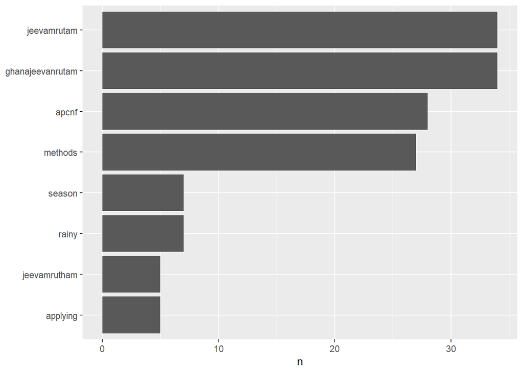

```r
tk1 %>% anti_join(stop_words) %>%
  count(word, sort = TRUE) %>%
  filter(n > 2) %>%
  mutate(word = reorder(word, n)) %>%
  ggplot(aes(n, word)) +
  geom_col() +
  labs(y = NULL)
```

Other methods used for enhancing the crop productivity are jeevamrutam, gvm and APCNF methods.

```r
df3$farm_management.crop_rotation <- as.factor(df3$farm_management.crop_rotation)
levels(df3$farm_management.crop_rotation) <- c("NO", "YES")

freq(df3$farm_management.crop_rotation)
```

```
## Frequencies
## df3$farm_management.crop_rotation
## Type: Factor
##
##               Freq   % Valid   % Valid Cum.   % Total   % Total Cum.
## ----------- ------ --------- -------------- --------- --------------
##          NO    255     43.00          43.00     43.00          43.00
##         YES    338     57.00         100.00     57.00         100.00
##        <NA>      0                               0.00         100.00
##       Total    593    100.00         100.00    100.00         100.00
```

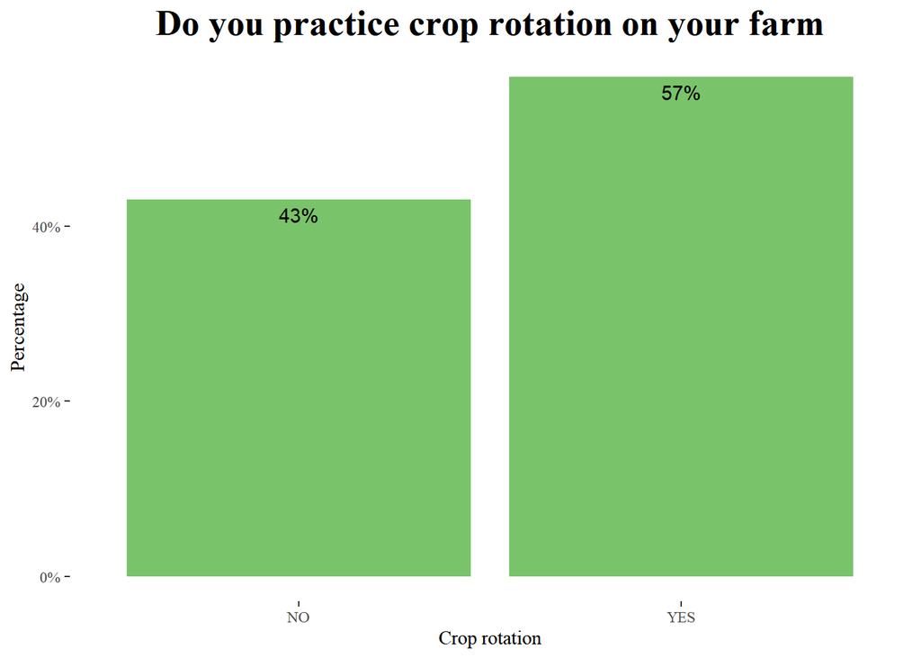

```r
df3 %>%drop_na(farm_management.crop_rotation) %>%  ggplot(aes(farm_management.crop_rotation))+
  geom_bar(fill = "#79c36a", aes(y = (..count..)/sum(..count..)))+
  geom_text(aes(y = ((..count..)/sum(..count..)), label = scales::percent((..count..)/sum(..count..))), stat = "count", vjust = 1.5, colour = "black")+
  scale_y_continuous(labels = percent) +
  labs(title = "Do you practice crop rotation on your farm",
       x = "Crop rotation",
       y="Percentage")+
  theme_tufte()+
  theme(plot.title = element_text(face = "bold", size = 20, hjust = 0.5))
```

57% of the farmers practice crop rotation on their farms.

```r
table(df3$farm_management.fallowing)
```

```
##
##   0   1
## 446 147
```

```r
df3$farm_management.fallowing <- as.factor(df3$farm_management.fallowing)
levels(df3$farm_management.fallowing) <- c("NO", "YES")

freq(df3$farm_management.fallowing)
```

```
## Frequencies
## df3$farm_management.fallowing
## Type: Factor
##
##               Freq   % Valid   % Valid Cum.   % Total   % Total Cum.
## ----------- ------ --------- -------------- --------- --------------
##          NO    446     75.21          75.21     75.21          75.21
##         YES    147     24.79         100.00     24.79         100.00
##        <NA>      0                               0.00         100.00
##       Total    593    100.00         100.00    100.00         100.00
```

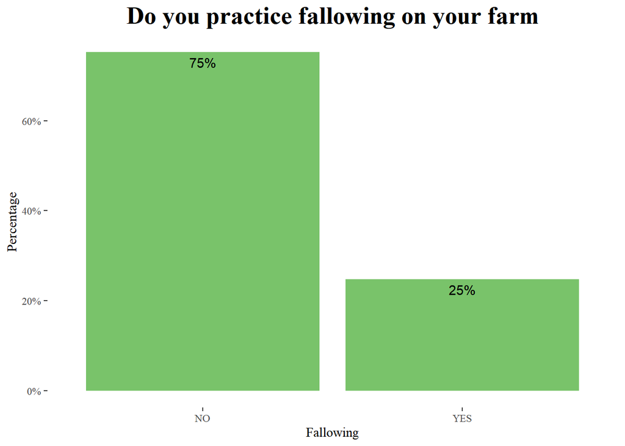

```r
df3 %>%drop_na(farm_management.fallowing) %>%  ggplot(aes(farm_management.fallowing))+
  geom_bar(fill = "#79c36a", aes(y = (..count..)/sum(..count..)))+
  geom_text(aes(y = ((..count..)/sum(..count..)), label = scales::percent((..count..)/sum(..count..))), stat = "count", vjust = 1.5, colour = "black")+
  scale_y_continuous(labels = percent) +
  labs(title = "Do you practice fallowing on your farm",
       x = "Fallowing",
       y="Percentage")+
  theme_tufte()+
  theme(plot.title = element_text(face = "bold", size = 20, hjust = 0.5))
```

25% of the farmers practice fallowing on the farm.

```r
summary(df3$farm_management.fallow_percent)
```

```
##    Min. 1st Qu.  Median    Mean 3rd Qu.    Max.    NA's
##    0.10   30.00   50.00   49.88   60.00  100.00     446
```

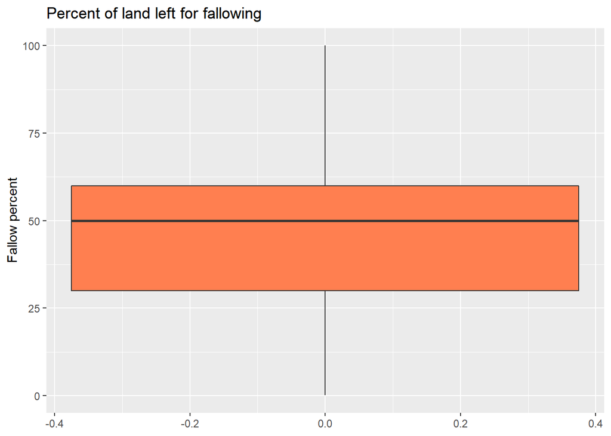

```r
df3 %>% ggplot(aes(y = farm_management.fallow_percent))+
  geom_boxplot(fill = "coral")+
  labs(y = "Fallow percent",
       title = "Percent of land left for fallowing")
```

The farm management in terms fallow percent its minimum is 0.1, and maximum is 100 this means that there are those who practice fallowing 100% on there farms.

```r
summary(df3$farm_management.fallow_years)
```

```
##    Min. 1st Qu.  Median    Mean 3rd Qu.    Max.    NA's
##   0.250   0.500   1.000   1.011   1.000   7.000     446
```

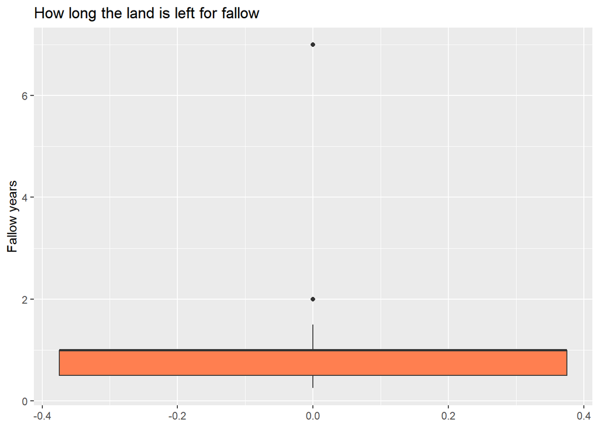

```r
df3 %>% ggplot(aes(y = farm_management.fallow_years))+
  geom_boxplot(fill = "coral")+
  labs(y = "Fallow years",
       title = "How long the land is left for fallow")
```

maximum number of years for fallowing is 7 years and minimum is 0.25.

```r
df3$farm_management.burning <- as.factor(df3$farm_management.burning)
levels(df3$farm_management.burning) <- c("NO", "YES")

freq(df3$farm_management.burning)
```

```
## Frequencies
## df3$farm_management.burning
## Type: Factor
##
##               Freq   % Valid   % Valid Cum.   % Total   % Total Cum.
## ----------- ------ --------- -------------- --------- --------------
##          NO    584     98.48          98.48     98.48          98.48
##         YES      9      1.52         100.00      1.52         100.00
##        <NA>      0                               0.00         100.00
##       Total    593    100.00         100.00    100.00         100.00
```